# **Problem Statement**

## Business Context

Renewable energy sources play an increasingly important role in the global energy mix, as the effort to reduce the environmental impact of energy production increases.

Out of all the renewable energy alternatives, wind energy is one of the most developed technologies worldwide. The U.S Department of Energy has put together a guide to achieving operational efficiency using predictive maintenance practices.

Predictive maintenance uses sensor information and analysis methods to measure and predict degradation and future component capability. The idea behind predictive maintenance is that failure patterns are predictable and if component failure can be predicted accurately and the component is replaced before it fails, the costs of operation and maintenance will be much lower.

The sensors fitted across different machines involved in the process of energy generation collect data related to various environmental factors (temperature, humidity, wind speed, etc.) and additional features related to various parts of the wind turbine (gearbox, tower, blades, break, etc.).

## Objective

“ReneWind” is a company working on improving the machinery/processes involved in the production of wind energy using machine learning and has collected data of generator failure of wind turbines using sensors. They have shared a ciphered version of the data, as the data collected through sensors is confidential (the type of data collected varies with companies). Data has 40 predictors, 20000 observations in the training set and 5000 in the test set.

The objective is to build various classification models, tune them, and find the best one that will help identify failures so that the generators could be repaired before failing/breaking to reduce the overall maintenance cost. The nature of predictions made by the classification model will translate as follows:

- True positives (TP) are failures correctly predicted by the model. These will result in repairing costs.
- False negatives (FN) are real failures where there is no detection by the model. These will result in replacement costs.
- False positives (FP) are detections where there is no failure. These will result in inspection costs.

It is given that the cost of repairing a generator is much less than the cost of replacing it, and the cost of inspection is less than the cost of repair.

“1” in the target variables should be considered as “failure” and “0” represents “No failure”.

## Data Description

The data provided is a transformed version of the original data which was collected using sensors.

- Train.csv - To be used for training and tuning of models.
- Test.csv - To be used only for testing the performance of the final best model.

Both the datasets consist of 40 predictor variables and 1 target variable.

# **Importing necessary libraries**

```python
# Library for data manipulation and analysis.
import pandas as pd
# Fundamental package for scientific computing.
import numpy as np
#splitting datasets into training and testing sets.
from sklearn.model_selection import train_test_split
#Imports tools for data preprocessing including label encoding, one-hot encoding, and standard scaling
from sklearn.preprocessing import LabelEncoder, OneHotEncoder,StandardScaler
#Imports a class for imputing missing values in datasets.
from sklearn.impute import SimpleImputer
#Imports the Matplotlib library for creating visualizations.
from sklearn.metrics import confusion_matrix
import matplotlib.pyplot as plt
# Imports the Seaborn library for statistical data visualization.
import seaborn as sns
# Time related functions.
import time
#Imports functions for evaluating the performance of machine learning models
from sklearn.metrics import confusion_matrix, f1_score,accuracy_score, recall_score, precision_score, classification_report
#Imports metrics from
from sklearn import metrics
#Imports the class for computing class weights to handle imbalanced datasets.
from sklearn.utils import class_weight
# Suppress TensorFlow warnings
import os
os.environ['TF_CPP_MIN_LOG_LEVEL'] = '3'

#Imports the tensorflow,keras and layers.
import tensorflow
import tensorflow as tf
from tensorflow.keras.models import Sequential
from tensorflow.keras.layers import Dense
from tensorflow.keras.layers import Dense, Input, Dropout,BatchNormalization
from tensorflow.keras.callbacks import EarlyStopping
from tensorflow.keras import backend

# to suppress unnecessary warnings
import warnings
warnings.filterwarnings('ignore')
from sklearn.exceptions import UndefinedMetricWarning
warnings.filterwarnings('ignore', category=UndefinedMetricWarning)
start_project = time.time()
```

# **Loading the Data**

```python
df = pd.read_csv("Train.csv")
df_test = pd.read_csv("Test.csv")
```

# **Data Overview**

## Checking the shape of the dataset

```python
df.shape
```

```
(20000, 41)
```

```python
df_test.shape
```

```
(5000, 41)
```

## Copying the datasets

```python
data = df.copy()
```

```python
data_test = df_test.copy()
```

## Displaying the first few rows of the dataset

```python
data.head()
```

|  | V1 | V2 | V3 | V4 | V5 | V6 | V7 | V8 | V9 | V10 | ... | V32 | V33 | V34 | V35 | V36 | V37 | V38 | V39 | V40 | Target |
| --- | --- | --- | --- | --- | --- | --- | --- | --- | --- | --- | --- | --- | --- | --- | --- | --- | --- | --- | --- | --- | --- |
| 0 | -4.464606 | -4.679129 | 3.101546 | 0.506130 | -0.221083 | -2.032511 | -2.910870 | 0.050714 | -1.522351 | 3.761892 | ... | 3.059700 | -1.690440 | 2.846296 | 2.235198 | 6.667486 | 0.443809 | -2.369169 | 2.950578 | -3.480324 | 0 |
| 1 | 3.365912 | 3.653381 | 0.909671 | -1.367528 | 0.332016 | 2.358938 | 0.732600 | -4.332135 | 0.565695 | -0.101080 | ... | -1.795474 | 3.032780 | -2.467514 | 1.894599 | -2.297780 | -1.731048 | 5.908837 | -0.386345 | 0.616242 | 0 |
| 2 | -3.831843 | -5.824444 | 0.634031 | -2.418815 | -1.773827 | 1.016824 | -2.098941 | -3.173204 | -2.081860 | 5.392621 | ... | -0.257101 | 0.803550 | 4.086219 | 2.292138 | 5.360850 | 0.351993 | 2.940021 | 3.839160 | -4.309402 | 0 |
| 3 | 1.618098 | 1.888342 | 7.046143 | -1.147285 | 0.083080 | -1.529780 | 0.207309 | -2.493629 | 0.344926 | 2.118578 | ... | -3.584425 | -2.577474 | 1.363769 | 0.622714 | 5.550100 | -1.526796 | 0.138853 | 3.101430 | -1.277378 | 0 |
| 4 | -0.111440 | 3.872488 | -3.758361 | -2.982897 | 3.792714 | 0.544960 | 0.205433 | 4.848994 | -1.854920 | -6.220023 | ... | 8.265896 | 6.629213 | -10.068689 | 1.222987 | -3.229763 | 1.686909 | -2.163896 | -3.644622 | 6.510338 | 0 |

5 rows × 41 columns

```python
data_test.head()
```

|  | V1 | V2 | V3 | V4 | V5 | V6 | V7 | V8 | V9 | V10 | ... | V32 | V33 | V34 | V35 | V36 | V37 | V38 | V39 | V40 | Target |
| --- | --- | --- | --- | --- | --- | --- | --- | --- | --- | --- | --- | --- | --- | --- | --- | --- | --- | --- | --- | --- | --- |
| 0 | -0.613489 | -3.819640 | 2.202302 | 1.300420 | -1.184929 | -4.495964 | -1.835817 | 4.722989 | 1.206140 | -0.341909 | ... | 2.291204 | -5.411388 | 0.870073 | 0.574479 | 4.157191 | 1.428093 | -10.511342 | 0.454664 | -1.448363 | 0 |
| 1 | 0.389608 | -0.512341 | 0.527053 | -2.576776 | -1.016766 | 2.235112 | -0.441301 | -4.405744 | -0.332869 | 1.966794 | ... | -2.474936 | 2.493582 | 0.315165 | 2.059288 | 0.683859 | -0.485452 | 5.128350 | 1.720744 | -1.488235 | 0 |
| 2 | -0.874861 | -0.640632 | 4.084202 | -1.590454 | 0.525855 | -1.957592 | -0.695367 | 1.347309 | -1.732348 | 0.466500 | ... | -1.318888 | -2.997464 | 0.459664 | 0.619774 | 5.631504 | 1.323512 | -1.752154 | 1.808302 | 1.675748 | 0 |
| 3 | 0.238384 | 1.458607 | 4.014528 | 2.534478 | 1.196987 | -3.117330 | -0.924035 | 0.269493 | 1.322436 | 0.702345 | ... | 3.517918 | -3.074085 | -0.284220 | 0.954576 | 3.029331 | -1.367198 | -3.412140 | 0.906000 | -2.450889 | 0 |
| 4 | 5.828225 | 2.768260 | -1.234530 | 2.809264 | -1.641648 | -1.406698 | 0.568643 | 0.965043 | 1.918379 | -2.774855 | ... | 1.773841 | -1.501573 | -2.226702 | 4.776830 | -6.559698 | -0.805551 | -0.276007 | -3.858207 | -0.537694 | 0 |

5 rows × 41 columns

## Checking the data types of the columns in the dataset

```python
data.dtypes
```

```
V1        float64
V2        float64
V3        float64
V4        float64
V5        float64
V6        float64
V7        float64
V8        float64
V9        float64
V10       float64
V11       float64
V12       float64
V13       float64
V14       float64
V15       float64
V16       float64
V17       float64
V18       float64
V19       float64
V20       float64
V21       float64
V22       float64
V23       float64
V24       float64
V25       float64
V26       float64
V27       float64
V28       float64
V29       float64
V30       float64
V31       float64
V32       float64
V33       float64
V34       float64
V35       float64
V36       float64
V37       float64
V38       float64
V39       float64
V40       float64
Target      int64
dtype: object
```

- Converting Target column to float

```python
data['Target'] = data['Target'].astype(float)
```

- Now with Test data

```python
data_test.dtypes
```

```
V1        float64
V2        float64
V3        float64
V4        float64
V5        float64
V6        float64
V7        float64
V8        float64
V9        float64
V10       float64
V11       float64
V12       float64
V13       float64
V14       float64
V15       float64
V16       float64
V17       float64
V18       float64
V19       float64
V20       float64
V21       float64
V22       float64
V23       float64
V24       float64
V25       float64
V26       float64
V27       float64
V28       float64
V29       float64
V30       float64
V31       float64
V32       float64
V33       float64
V34       float64
V35       float64
V36       float64
V37       float64
V38       float64
V39       float64
V40       float64
Target      int64
dtype: object
```

```python
data_test['Target'] = data_test['Target'].astype(float)
```

## Checking for missing values

```python
data.isnull().sum()
```

```
V1        18
V2        18
V3         0
V4         0
V5         0
V6         0
V7         0
V8         0
V9         0
V10        0
V11        0
V12        0
V13        0
V14        0
V15        0
V16        0
V17        0
V18        0
V19        0
V20        0
V21        0
V22        0
V23        0
V24        0
V25        0
V26        0
V27        0
V28        0
V29        0
V30        0
V31        0
V32        0
V33        0
V34        0
V35        0
V36        0
V37        0
V38        0
V39        0
V40        0
Target     0
dtype: int64
```

```python
data_test.isnull().sum()
```

```
V1        5
V2        6
V3        0
V4        0
V5        0
V6        0
V7        0
V8        0
V9        0
V10       0
V11       0
V12       0
V13       0
V14       0
V15       0
V16       0
V17       0
V18       0
V19       0
V20       0
V21       0
V22       0
V23       0
V24       0
V25       0
V26       0
V27       0
V28       0
V29       0
V30       0
V31       0
V32       0
V33       0
V34       0
V35       0
V36       0
V37       0
V38       0
V39       0
V40       0
Target    0
dtype: int64
```

## Statistical summary of the dataset

```python
data.describe()
```

|  | V1 | V2 | V3 | V4 | V5 | V6 | V7 | V8 | V9 | V10 | ... | V32 | V33 | V34 | V35 | V36 | V37 | V38 | V39 | V40 | Target |
| --- | --- | --- | --- | --- | --- | --- | --- | --- | --- | --- | --- | --- | --- | --- | --- | --- | --- | --- | --- | --- | --- |
| count | 19982.000000 | 19982.000000 | 20000.000000 | 20000.000000 | 20000.000000 | 20000.000000 | 20000.000000 | 20000.000000 | 20000.000000 | 20000.000000 | ... | 20000.000000 | 20000.000000 | 20000.000000 | 20000.000000 | 20000.000000 | 20000.000000 | 20000.000000 | 20000.000000 | 20000.000000 | 20000.000000 |
| mean | -0.271996 | 0.440430 | 2.484699 | -0.083152 | -0.053752 | -0.995443 | -0.879325 | -0.548195 | -0.016808 | -0.012998 | ... | 0.303799 | 0.049825 | -0.462702 | 2.229620 | 1.514809 | 0.011316 | -0.344025 | 0.890653 | -0.875630 | 0.055500 |
| std | 3.441625 | 3.150784 | 3.388963 | 3.431595 | 2.104801 | 2.040970 | 1.761626 | 3.295756 | 2.160568 | 2.193201 | ... | 5.500400 | 3.575285 | 3.183841 | 2.937102 | 3.800860 | 1.788165 | 3.948147 | 1.753054 | 3.012155 | 0.228959 |
| min | -11.876451 | -12.319951 | -10.708139 | -15.082052 | -8.603361 | -10.227147 | -7.949681 | -15.657561 | -8.596313 | -9.853957 | ... | -19.876502 | -16.898353 | -17.985094 | -15.349803 | -14.833178 | -5.478350 | -17.375002 | -6.438880 | -11.023935 | 0.000000 |
| 25% | -2.737146 | -1.640674 | 0.206860 | -2.347660 | -1.535607 | -2.347238 | -2.030926 | -2.642665 | -1.494973 | -1.411212 | ... | -3.420469 | -2.242857 | -2.136984 | 0.336191 | -0.943809 | -1.255819 | -2.987638 | -0.272250 | -2.940193 | 0.000000 |
| 50% | -0.747917 | 0.471536 | 2.255786 | -0.135241 | -0.101952 | -1.000515 | -0.917179 | -0.389085 | -0.067597 | 0.100973 | ... | 0.052073 | -0.066249 | -0.255008 | 2.098633 | 1.566526 | -0.128435 | -0.316849 | 0.919261 | -0.920806 | 0.000000 |
| 75% | 1.840112 | 2.543967 | 4.566165 | 2.130615 | 1.340480 | 0.380330 | 0.223695 | 1.722965 | 1.409203 | 1.477045 | ... | 3.761722 | 2.255134 | 1.436935 | 4.064358 | 3.983939 | 1.175533 | 2.279399 | 2.057540 | 1.119897 | 0.000000 |
| max | 15.493002 | 13.089269 | 17.090919 | 13.236381 | 8.133797 | 6.975847 | 8.006091 | 11.679495 | 8.137580 | 8.108472 | ... | 23.633187 | 16.692486 | 14.358213 | 15.291065 | 19.329576 | 7.467006 | 15.289923 | 7.759877 | 10.654265 | 1.000000 |

8 rows × 41 columns

```python
data_test.describe()
```

|  | V1 | V2 | V3 | V4 | V5 | V6 | V7 | V8 | V9 | V10 | ... | V32 | V33 | V34 | V35 | V36 | V37 | V38 | V39 | V40 | Target |
| --- | --- | --- | --- | --- | --- | --- | --- | --- | --- | --- | --- | --- | --- | --- | --- | --- | --- | --- | --- | --- | --- |
| count | 4995.000000 | 4994.000000 | 5000.000000 | 5000.000000 | 5000.000000 | 5000.000000 | 5000.000000 | 5000.000000 | 5000.000000 | 5000.000000 | ... | 5000.000000 | 5000.000000 | 5000.000000 | 5000.000000 | 5000.000000 | 5000.000000 | 5000.000000 | 5000.000000 | 5000.000000 | 5000.000000 |
| mean | -0.277622 | 0.397928 | 2.551787 | -0.048943 | -0.080120 | -1.042138 | -0.907922 | -0.574592 | 0.030121 | 0.018524 | ... | 0.232567 | -0.080115 | -0.392663 | 2.211205 | 1.594845 | 0.022931 | -0.405659 | 0.938800 | -0.932406 | 0.056400 |
| std | 3.466280 | 3.139562 | 3.326607 | 3.413937 | 2.110870 | 2.005444 | 1.769017 | 3.331911 | 2.174139 | 2.145437 | ... | 5.585628 | 3.538624 | 3.166101 | 2.948426 | 3.774970 | 1.785320 | 3.968936 | 1.716502 | 2.978193 | 0.230716 |
| min | -12.381696 | -10.716179 | -9.237940 | -14.682446 | -7.711569 | -8.924196 | -8.124230 | -12.252731 | -6.785495 | -8.170956 | ... | -17.244168 | -14.903781 | -14.699725 | -12.260591 | -12.735567 | -5.079070 | -15.334533 | -5.451050 | -10.076234 | 0.000000 |
| 25% | -2.743691 | -1.649211 | 0.314931 | -2.292694 | -1.615238 | -2.368853 | -2.054259 | -2.642088 | -1.455712 | -1.353320 | ... | -3.556267 | -2.348121 | -2.009604 | 0.321818 | -0.866066 | -1.240526 | -2.984480 | -0.208024 | -2.986587 | 0.000000 |
| 50% | -0.764767 | 0.427369 | 2.260428 | -0.145753 | -0.131890 | -1.048571 | -0.939695 | -0.357943 | -0.079891 | 0.166292 | ... | -0.076694 | -0.159713 | -0.171745 | 2.111750 | 1.702964 | -0.110415 | -0.381162 | 0.959152 | -1.002764 | 0.000000 |
| 75% | 1.831313 | 2.444486 | 4.587000 | 2.166468 | 1.341197 | 0.307555 | 0.212228 | 1.712896 | 1.449548 | 1.511248 | ... | 3.751857 | 2.099160 | 1.465402 | 4.031639 | 4.104409 | 1.237522 | 2.287998 | 2.130769 | 1.079738 | 0.000000 |
| max | 13.504352 | 14.079073 | 15.314503 | 12.140157 | 7.672835 | 5.067685 | 7.616182 | 10.414722 | 8.850720 | 6.598728 | ... | 26.539391 | 13.323517 | 12.146302 | 13.489237 | 17.116122 | 6.809938 | 13.064950 | 7.182237 | 8.698460 | 1.000000 |

8 rows × 41 columns

### 📌 Data Overview – Insight

The dataset consists of 20,000 training and 5,000 test observations, with 40 numerical predictor variables and 1 binary target variable representing failure (1) or no failure (0). Despite the ciphered nature of the features, the variables show sufficient variability and scaling to support predictive modeling.

The dataset structure and volume are appropriate for training neural networks with generalization capability.

# **Exploratory Data Analysis**

## Univariate analysis

```python
def histogram_boxplot(data, feature, figsize=(12, 7), kde=False, bins=None):
    """
    Boxplot and histogram combined

    data: dataframe
    feature: dataframe column
    figsize: size of figure (default (12,7))
    kde: whether to the show density curve (default False)
    bins: number of bins for histogram (default None)
    """
    f2, (ax_box2, ax_hist2) = plt.subplots(
        nrows=2,  # Number of rows of the subplot grid= 2
        sharex=True,  # x-axis will be shared among all subplots
        gridspec_kw={"height_ratios": (0.25, 0.75)},
        figsize=figsize,
    )  # creating the 2 subplots
    sns.boxplot(
        data= data, x= feature, ax= ax_hist2, showmeans=True, color="violet"
    )  # boxplot will be created and a star will indicate the mean value of the column
    sns.histplot(
        data=data, x=feature, kde=kde, ax=ax_hist2, bins=bins, palette="winter"
    ) if bins else sns.histplot(
        data=data, x=feature, kde=kde, ax=ax_hist2
    )  # For histogram
    ax_hist2.axvline(
        data[feature].mean(), color="green", linestyle="--"
    )  # Add mean to the histogram
    ax_hist2.axvline(
        data[feature].median(), color="black", linestyle="-"
    )  # Add median to the histogram
```

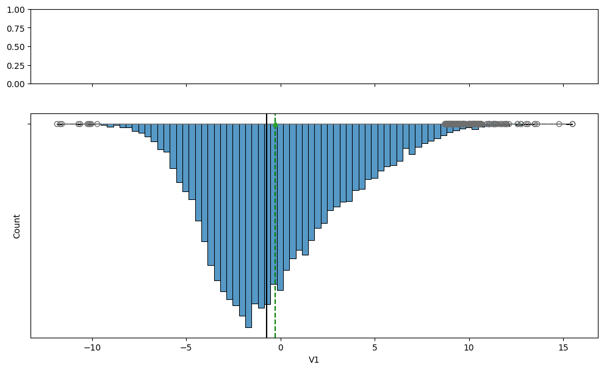

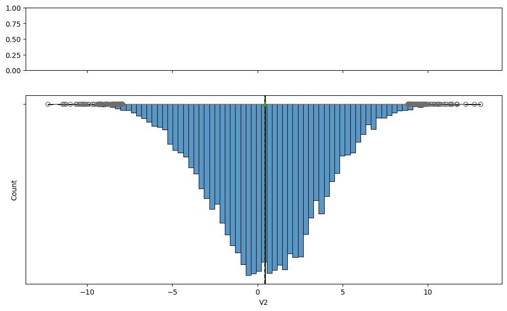

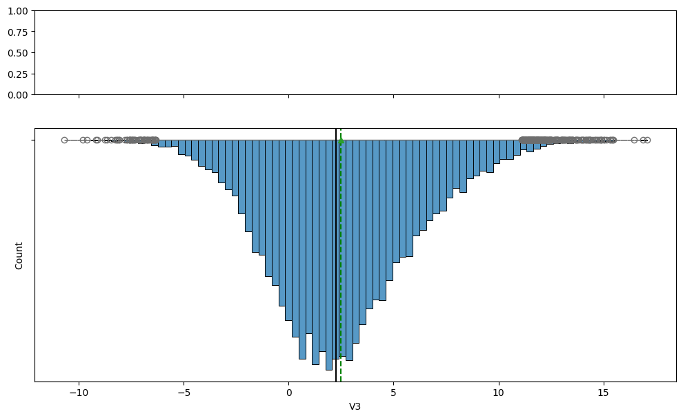

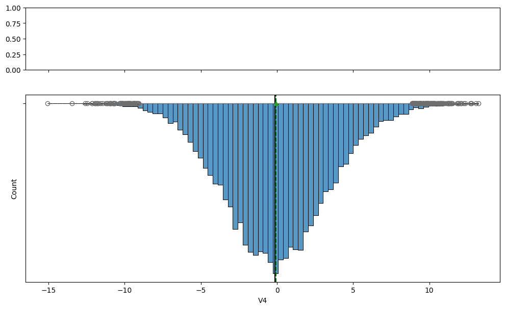

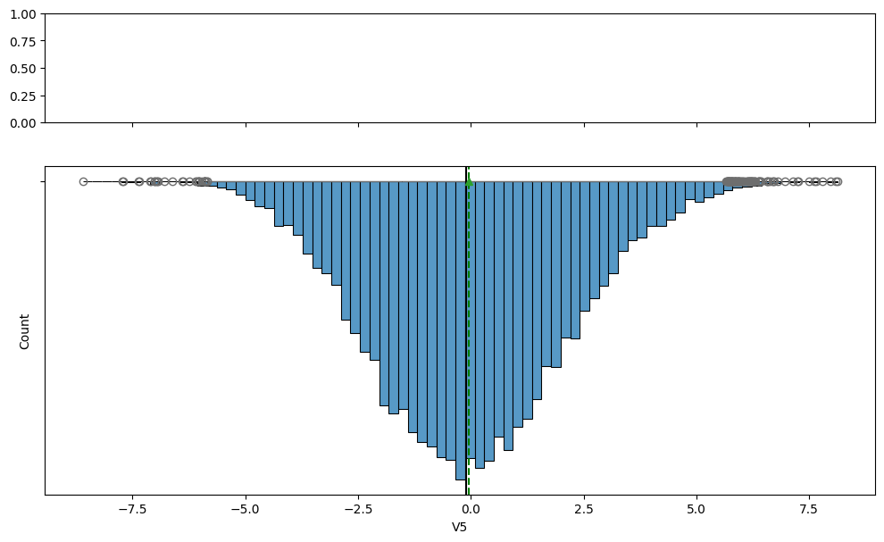

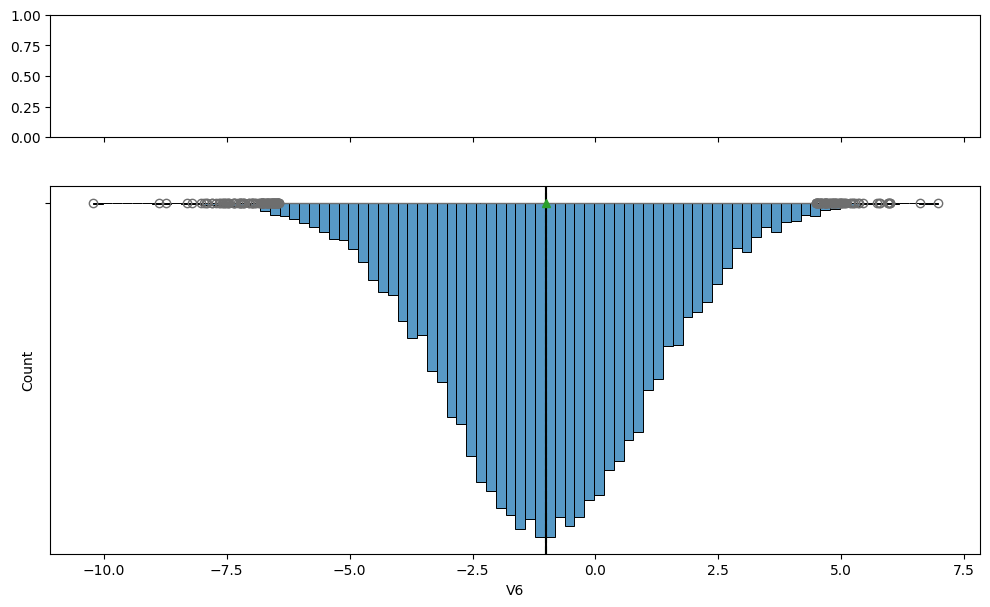

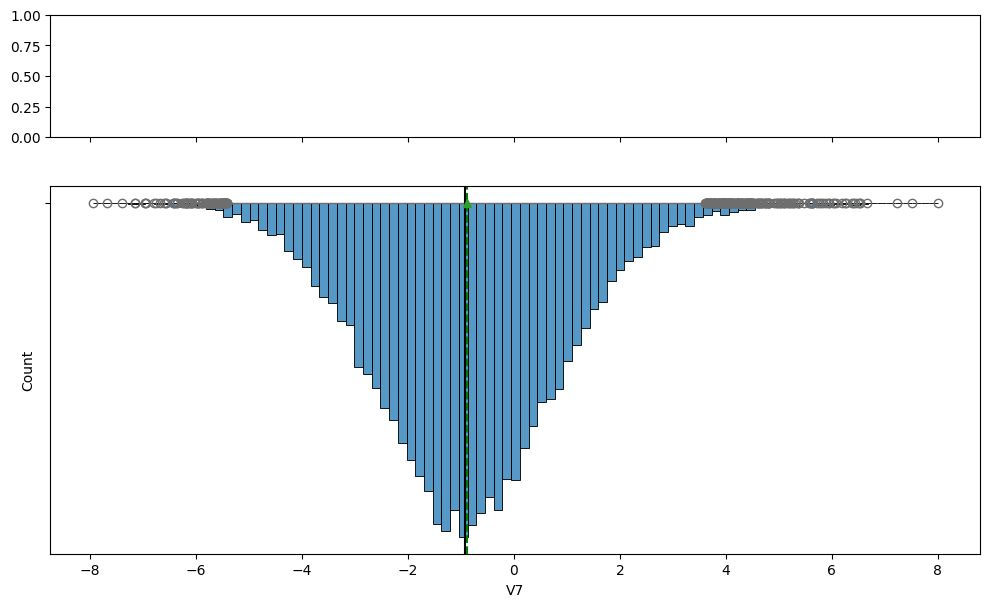

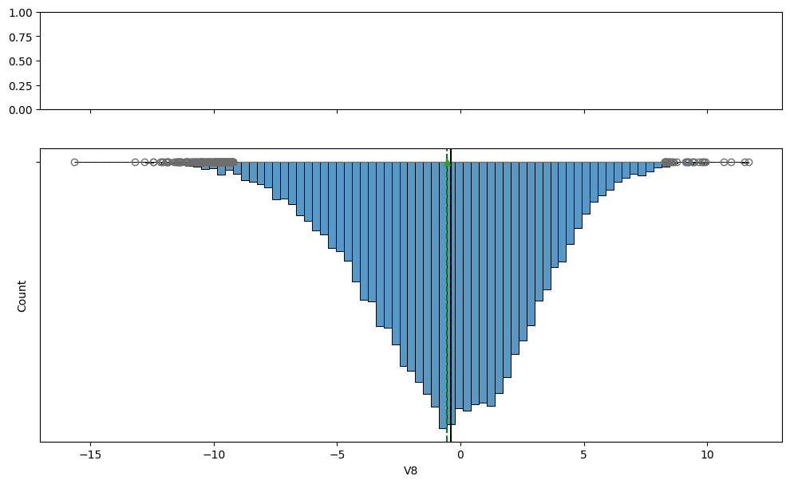

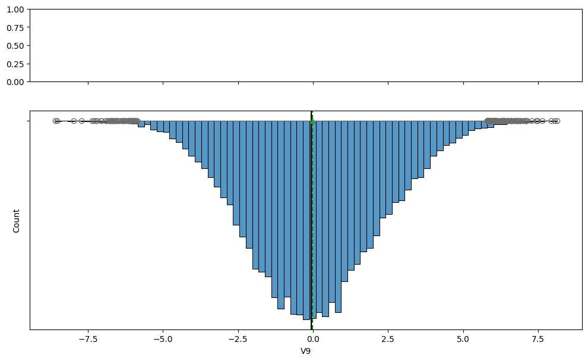

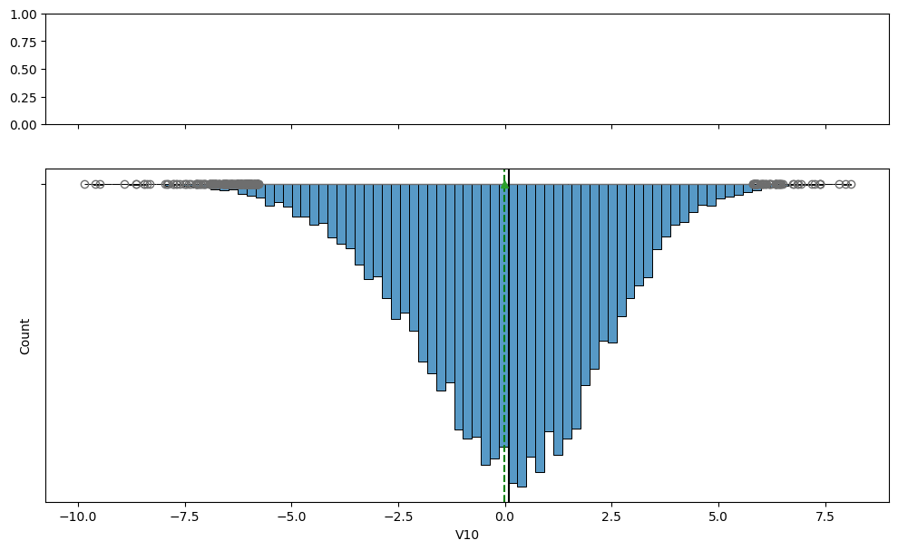

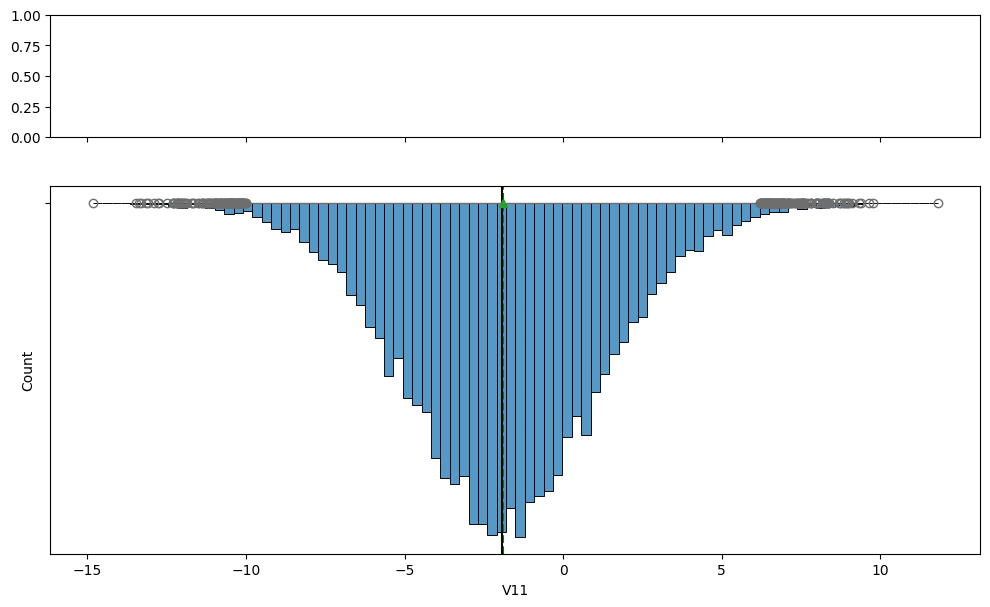

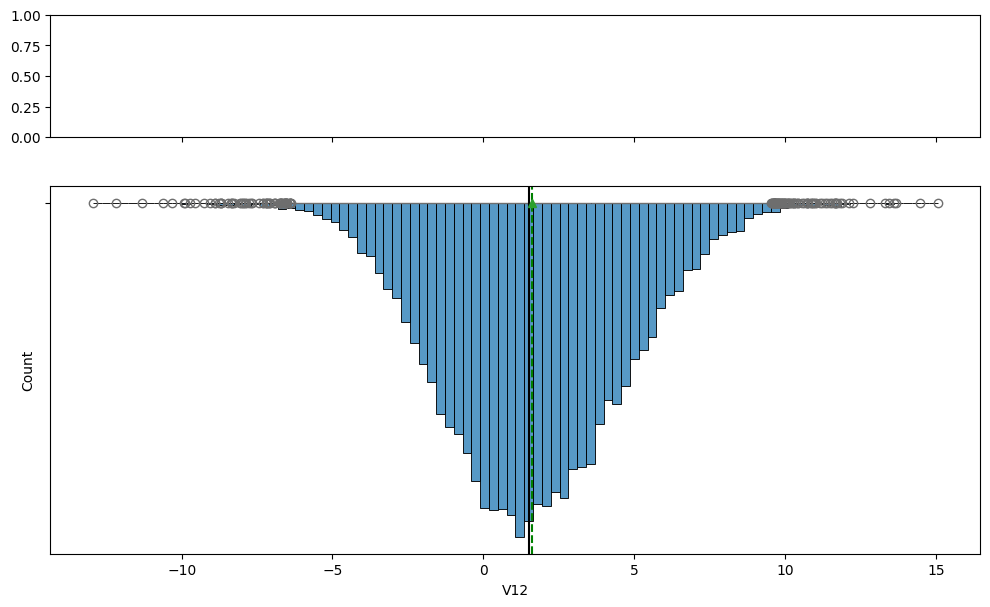

[29 more figures not shown]

```python
for feature in data.columns:
    histogram_boxplot(data, feature, figsize=(12, 7), kde=False, bins=None)
```

### Checking the distrubution of Target variable

```python
data["Target"].value_counts()
```

```
Target
0.0    18890
1.0     1110
Name: count, dtype: int64
```

```python
data_test["Target"].value_counts()
```

```
Target
0.0    4718
1.0     282
Name: count, dtype: int64
```

## Bivariate Analysis

### Correlation Check

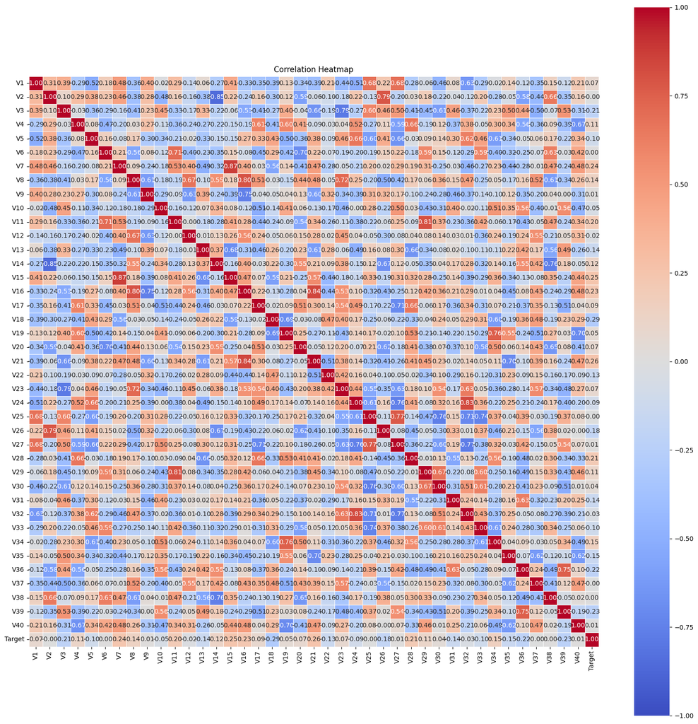

```python
plt.figure(figsize=(20, 20))
sns.heatmap(
    data.corr(), annot=True, vmin=-1, vmax=1, fmt=".2f",
    cmap="coolwarm", square=True, linewidths=0.5
)
plt.title("Correlation Heatmap")
plt.show()
```

### 📌 EDA Summary Insights

Importantly, the class distribution is significantly imbalanced (~95% class 0 vs. 5% class 1), which directly influences model selection and evaluation metrics. Precision, recall, and F1 score are more meaningful than accuracy for this classification task.

The data is clean, consistent, and informative, supporting effective model training.

# **Data Preprocessing**

## Data Preparation for Modeling

```python
X = data.drop(columns=["Target"], axis=1)
y = data["Target"]
```

**Since we already have a separate test set, we don't need to divide data into train, valiation and test**

```python
X_train, X_val, y_train, y_val = train_test_split(
    X, y, test_size=0.25, random_state=1, stratify=y
)
```

```python
X_train.shape
```

```
(15000, 40)
```

```python
X_val.shape
```

```
(5000, 40)
```

```python
X_test = data_test.drop(columns=['Target'], axis=1)
y_test = data_test['Target']
```

```python
X_test.shape
```

```
(5000, 40)
```

## Missing Value Imputation

```python
imputer = SimpleImputer(strategy="median")
```

```python
# Fit and transform the train data
X_train = pd.DataFrame(imputer.fit_transform(X_train), columns=X_train.columns)

# Transform the validation data
X_val = pd.DataFrame(imputer.transform(X_val), columns=X_train.columns)

# Transform the test data
X_test = pd.DataFrame(imputer.transform(X_test), columns=X_train.columns)
```

```python
# Checking that no column has missing values in train or test sets
print(X_train.isna().sum())
print("-" * 30)
print(X_val.isna().sum())
print("-" * 30)
print(X_test.isna().sum())
```

```
V1     0
V2     0
V3     0
V4     0
V5     0
V6     0
V7     0
V8     0
V9     0
V10    0
V11    0
V12    0
V13    0
V14    0
V15    0
V16    0
V17    0
V18    0
V19    0
V20    0
V21    0
V22    0
V23    0
V24    0
V25    0
V26    0
V27    0
V28    0
V29    0
V30    0
V31    0
V32    0
V33    0
V34    0
V35    0
V36    0
V37    0
V38    0
V39    0
V40    0
```

[output cut: 70 more lines]

```
V27    0
V28    0
V29    0
V30    0
V31    0
V32    0
V33    0
V34    0
V35    0
V36    0
V37    0
V38    0
V39    0
V40    0
dtype: int64
```

```python
y_train = y_train.to_numpy()
y_val = y_val.to_numpy()
y_test = y_test.to_numpy()
```

# **Model Building**

## Utility Functions

```python
def plot(history, name):
    """
    Function to plot loss/accuracy

    history: an object which stores the metrics and losses.
    name: can be one of Loss or Accuracy
    """
    fig, ax = plt.subplots() #Creating a subplot with figure and axes.
    plt.plot(history.history[name]) #Plotting the train accuracy or train loss
    plt.plot(history.history['val_'+name]) #Plotting the validation accuracy or validation loss

    plt.title('Model ' + name.capitalize()) #Defining the title of the plot.
    plt.ylabel(name.capitalize()) #Capitalizing the first letter.
    plt.xlabel('Epoch') #Defining the label for the x-axis.
    fig.legend(['Train', 'Validation'], loc="outside right upper") #Defining the legend, loc controls the position of the legend.
```

```python
# defining a function to compute different metrics to check performance of a classification model built using statsmodels
def model_performance_classification(
    model, predictors, target, threshold=0.5
):
    """
    Function to compute different metrics to check classification model performance

    model: classifier
    predictors: independent variables
    target: dependent variable
    threshold: threshold for classifying the observation as class 1
    """

    # checking which probabilities are greater than threshold
    pred = model.predict(predictors) > threshold
    # pred_temp = model.predict(predictors) > threshold
    # # rounding off the above values to get classes
    # pred = np.round(pred_temp)

    acc = accuracy_score(target, pred)  # to compute Accuracy
    recall = recall_score(target, pred, average='macro')  # to compute Recall
    precision = precision_score(target, pred, average='macro')  # to compute Precision
    f1 = f1_score(target, pred, average='macro')  # to compute F1-score

    # creating a dataframe of metrics
    df_perf = pd.DataFrame(
        {"Accuracy": acc, "Recall": recall, "Precision": precision, "F1 Score": f1,}, index = [0]
    )

    return df_perf
```

## Initial Model Building (Model 0)

- Let's start with a neural network consisting of
  - just one hidden layer
  - activation function of ReLU
  - SGD as the optimizer

```python
# defining the batch size and # epochs upfront as we'll be using the same values for all models
epochs = 50
batch_size = 32
```

```python
# clears the current Keras session, resetting all layers and models previously created, freeing up memory and resources.
tf.keras.backend.clear_session()
```

```python
#Initializing the neural network
model_0 = Sequential()
model_0.add(Dense(64, activation="relu", input_shape=(X_train.shape[1],)))
model_0.add(Dense(1, activation="sigmoid"))
```

```python
model_0.summary()
```

```
Model: "sequential"
```

```
┏━━━━━━━━━━━━━━━━━━━━━━━━━━━━━━━━━┳━━━━━━━━━━━━━━━━━━━━━━━━┳━━━━━━━━━━━━━━━┓
┃ Layer (type)                    ┃ Output Shape           ┃       Param # ┃
┡━━━━━━━━━━━━━━━━━━━━━━━━━━━━━━━━━╇━━━━━━━━━━━━━━━━━━━━━━━━╇━━━━━━━━━━━━━━━┩
│ dense (Dense)                   │ (None, 64)             │         2,624 │
├─────────────────────────────────┼────────────────────────┼───────────────┤
│ dense_1 (Dense)                 │ (None, 1)              │            65 │
└─────────────────────────────────┴────────────────────────┴───────────────┘
```

```
 Total params: 2,689 (10.50 KB)
```

```
 Trainable params: 2,689 (10.50 KB)
```

```
 Non-trainable params: 0 (0.00 B)
```

```python
# Compiling the model with an optimizer, loss function, and evaluation metrics.
optimizer = tf.keras.optimizers.SGD(learning_rate=0.01)

model_0.compile(optimizer=optimizer, loss='binary_crossentropy', metrics=['Recall'])
```

```python
start = time.time()
history = model_0.fit(X_train, y_train, validation_data=(X_val,y_val) , batch_size=batch_size, epochs=epochs)
#using , callbacks=[early_stop] # to stop training when the validation loss stops improving
end=time.time()
```

```
469/469 ━━━━━━━━━━━━━━━━━━━━ 4s 6ms/step - Recall: 0.5971 - loss: 0.2515 - val_Recall: 0.6763 - val_loss: 0.1329
469/469 ━━━━━━━━━━━━━━━━━━━━ 3s 6ms/step - Recall: 0.6108 - loss: 0.1366 - val_Recall: 0.6655 - val_loss: 0.1294
469/469 ━━━━━━━━━━━━━━━━━━━━ 2s 5ms/step - Recall: 0.5901 - loss: 0.1291 - val_Recall: 0.5863 - val_loss: 0.1219
469/469 ━━━━━━━━━━━━━━━━━━━━ 2s 5ms/step - Recall: 0.5986 - loss: 0.1166 - val_Recall: 0.6007 - val_loss: 0.1277
469/469 ━━━━━━━━━━━━━━━━━━━━ 2s 5ms/step - Recall: 0.5127 - loss: 0.1244 - val_Recall: 0.5719 - val_loss: 0.1165
469/469 ━━━━━━━━━━━━━━━━━━━━ 3s 6ms/step - Recall: 0.5245 - loss: 0.1306 - val_Recall: 0.5755 - val_loss: 0.1171
469/469 ━━━━━━━━━━━━━━━━━━━━ 2s 5ms/step - Recall: 0.5339 - loss: 0.1186 - val_Recall: 0.5612 - val_loss: 0.1276
469/469 ━━━━━━━━━━━━━━━━━━━━ 2s 5ms/step - Recall: 0.5314 - loss: 0.1189 - val_Recall: 0.5144 - val_loss: 0.1145
469/469 ━━━━━━━━━━━━━━━━━━━━ 2s 5ms/step - Recall: 0.4899 - loss: 0.1238 - val_Recall: 0.5036 - val_loss: 0.1143
469/469 ━━━━━━━━━━━━━━━━━━━━ 3s 6ms/step - Recall: 0.5169 - loss: 0.1159 - val_Recall: 0.5216 - val_loss: 0.1204
469/469 ━━━━━━━━━━━━━━━━━━━━ 3s 5ms/step - Recall: 0.5251 - loss: 0.1191 - val_Recall: 0.4892 - val_loss: 0.1190
469/469 ━━━━━━━━━━━━━━━━━━━━ 2s 5ms/step - Recall: 0.5199 - loss: 0.1220 - val_Recall: 0.5324 - val_loss: 0.1233
469/469 ━━━━━━━━━━━━━━━━━━━━ 2s 5ms/step - Recall: 0.4854 - loss: 0.1317 - val_Recall: 0.5108 - val_loss: 0.1268
469/469 ━━━━━━━━━━━━━━━━━━━━ 3s 6ms/step - Recall: 0.5049 - loss: 0.1256 - val_Recall: 0.5144 - val_loss: 0.1210
469/469 ━━━━━━━━━━━━━━━━━━━━ 2s 5ms/step - Recall: 0.5118 - loss: 0.1243 - val_Recall: 0.4388 - val_loss: 0.1331
469/469 ━━━━━━━━━━━━━━━━━━━━ 2s 5ms/step - Recall: 0.4995 - loss: 0.1134 - val_Recall: 0.5036 - val_loss: 0.1310
469/469 ━━━━━━━━━━━━━━━━━━━━ 2s 5ms/step - Recall: 0.4704 - loss: 0.1319 - val_Recall: 0.5252 - val_loss: 0.1254
469/469 ━━━━━━━━━━━━━━━━━━━━ 3s 6ms/step - Recall: 0.5163 - loss: 0.1278 - val_Recall: 0.4640 - val_loss: 0.1290
469/469 ━━━━━━━━━━━━━━━━━━━━ 2s 5ms/step - Recall: 0.5186 - loss: 0.1293 - val_Recall: 0.4928 - val_loss: 0.1187
469/469 ━━━━━━━━━━━━━━━━━━━━ 2s 5ms/step - Recall: 0.4659 - loss: 0.1391 - val_Recall: 0.5324 - val_loss: 0.1295
469/469 ━━━━━━━━━━━━━━━━━━━━ 2s 5ms/step - Recall: 0.4800 - loss: 0.1533 - val_Recall: 0.4964 - val_loss: 0.1862
469/469 ━━━━━━━━━━━━━━━━━━━━ 3s 6ms/step - Recall: 0.5103 - loss: 0.1385 - val_Recall: 0.4604 - val_loss: 0.1215
469/469 ━━━━━━━━━━━━━━━━━━━━ 2s 5ms/step - Recall: 0.4998 - loss: 0.1440 - val_Recall: 0.4712 - val_loss: 0.1192
469/469 ━━━━━━━━━━━━━━━━━━━━ 2s 5ms/step - Recall: 0.4960 - loss: 0.1503 - val_Recall: 0.5252 - val_loss: 0.2212
469/469 ━━━━━━━━━━━━━━━━━━━━ 2s 5ms/step - Recall: 0.5060 - loss: 0.1705 - val_Recall: 0.4748 - val_loss: 0.1426
469/469 ━━━━━━━━━━━━━━━━━━━━ 3s 6ms/step - Recall: 0.4677 - loss: 0.2419 - val_Recall: 0.4964 - val_loss: 0.3250
469/469 ━━━━━━━━━━━━━━━━━━━━ 2s 5ms/step - Recall: 0.5162 - loss: 0.2014 - val_Recall: 0.5036 - val_loss: 0.2263
469/469 ━━━━━━━━━━━━━━━━━━━━ 3s 5ms/step - Recall: 0.4845 - loss: 0.2590 - val_Recall: 0.5288 - val_loss: 0.1566
469/469 ━━━━━━━━━━━━━━━━━━━━ 2s 5ms/step - Recall: 0.5325 - loss: 0.2972 - val_Recall: 0.4245 - val_loss: 0.4873
469/469 ━━━━━━━━━━━━━━━━━━━━ 3s 6ms/step - Recall: 0.5139 - loss: 0.3323 - val_Recall: 0.5252 - val_loss: 0.1554
469/469 ━━━━━━━━━━━━━━━━━━━━ 2s 5ms/step - Recall: 0.4991 - loss: 0.2920 - val_Recall: 0.5288 - val_loss: 0.2234
469/469 ━━━━━━━━━━━━━━━━━━━━ 2s 5ms/step - Recall: 0.5252 - loss: 0.3435 - val_Recall: 0.5468 - val_loss: 0.2986
469/469 ━━━━━━━━━━━━━━━━━━━━ 2s 5ms/step - Recall: 0.5582 - loss: 0.4374 - val_Recall: 0.5468 - val_loss: 0.3688
469/469 ━━━━━━━━━━━━━━━━━━━━ 3s 6ms/step - Recall: 0.5279 - loss: 0.5385 - val_Recall: 0.5324 - val_loss: 0.3367
469/469 ━━━━━━━━━━━━━━━━━━━━ 3s 5ms/step - Recall: 0.5767 - loss: 0.5296 - val_Recall: 0.5504 - val_loss: 1.2127
469/469 ━━━━━━━━━━━━━━━━━━━━ 2s 5ms/step - Recall: 0.5674 - loss: 0.7164 - val_Recall: 0.5827 - val_loss: 0.3069
469/469 ━━━━━━━━━━━━━━━━━━━━ 2s 5ms/step - Recall: 0.5629 - loss: 0.6410 - val_Recall: 0.5719 - val_loss: 0.3190
469/469 ━━━━━━━━━━━━━━━━━━━━ 3s 5ms/step - Recall: 0.5762 - loss: 1.3612 - val_Recall: 0.6007 - val_loss: 0.4121
469/469 ━━━━━━━━━━━━━━━━━━━━ 3s 5ms/step - Recall: 0.5535 - loss: 0.9295 - val_Recall: 0.5719 - val_loss: 0.5212
469/469 ━━━━━━━━━━━━━━━━━━━━ 3s 6ms/step - Recall: 0.5605 - loss: 1.0598 - val_Recall: 0.5432 - val_loss: 0.7809
469/469 ━━━━━━━━━━━━━━━━━━━━ 2s 5ms/step - Recall: 0.5682 - loss: 1.2853 - val_Recall: 0.5719 - val_loss: 0.7130
469/469 ━━━━━━━━━━━━━━━━━━━━ 3s 6ms/step - Recall: 0.5703 - loss: 1.6012 - val_Recall: 0.5504 - val_loss: 2.7789
469/469 ━━━━━━━━━━━━━━━━━━━━ 2s 5ms/step - Recall: 0.6073 - loss: 1.8027 - val_Recall: 0.6079 - val_loss: 0.9349
469/469 ━━━━━━━━━━━━━━━━━━━━ 2s 5ms/step - Recall: 0.6000 - loss: 2.1577 - val_Recall: 0.6151 - val_loss: 0.9710
469/469 ━━━━━━━━━━━━━━━━━━━━ 2s 5ms/step - Recall: 0.6151 - loss: 2.9339 - val_Recall: 0.6007 - val_loss: 4.6132
469/469 ━━━━━━━━━━━━━━━━━━━━ 3s 6ms/step - Recall: 0.5542 - loss: 3.1747 - val_Recall: 0.5252 - val_loss: 13.8115
469/469 ━━━━━━━━━━━━━━━━━━━━ 3s 6ms/step - Recall: 0.5609 - loss: 5.4331 - val_Recall: 0.6007 - val_loss: 8.9111
469/469 ━━━━━━━━━━━━━━━━━━━━ 3s 5ms/step - Recall: 0.5712 - loss: 4.5887 - val_Recall: 0.5755 - val_loss: 2.6705
469/469 ━━━━━━━━━━━━━━━━━━━━ 2s 5ms/step - Recall: 0.5957 - loss: 5.5744 - val_Recall: 0.5899 - val_loss: 2.6052
469/469 ━━━━━━━━━━━━━━━━━━━━ 3s 6ms/step - Recall: 0.5849 - loss: 7.6596 - val_Recall: 0.5971 - val_loss: 15.0105
```

```python
print("Time taken in seconds ",end-start)
```

```
Time taken in seconds  126.49565291404724
```

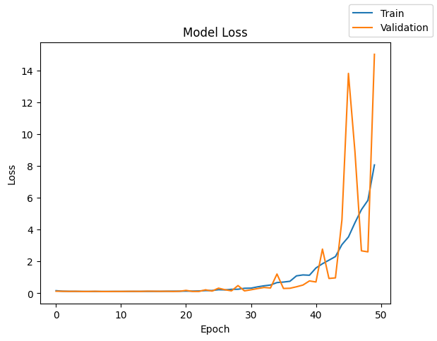

```python
plot(history,'loss')
```

Lets check the model performance of model_0 on training and validation data respectively.

```python
model_0_train_perf = model_performance_classification(model_0, X_train, y_train)
model_0_train_perf
```

```
469/469 ━━━━━━━━━━━━━━━━━━━━ 0s 949us/step
```

|  | Accuracy | Recall | Precision | F1 Score |
| --- | --- | --- | --- | --- |
| 0 | 0.8822 | 0.749273 | 0.616332 | 0.64803 |

```python
model_0_val_perf = model_performance_classification(model_0, X_val, y_val)
model_0_val_perf
```

```
157/157 ━━━━━━━━━━━━━━━━━━━━ 0s 981us/step
```

|  | Accuracy | Recall | Precision | F1 Score |
| --- | --- | --- | --- | --- |
| 0 | 0.8788 | 0.746253 | 0.612854 | 0.643536 |

Let's check the classification reports.

```python
y_train_pred_0 = model_0.predict(X_train)
y_val_pred_0 = model_0.predict(X_val)
```

```
469/469 ━━━━━━━━━━━━━━━━━━━━ 0s 898us/step
157/157 ━━━━━━━━━━━━━━━━━━━━ 0s 1ms/step
```

Lets check the classification report of model_0 on training and validation data respectively.

```python
print("Classification Report - Train data Model_0",end="\n\n")
cr_train_model_0 = classification_report(y_train,y_train_pred_0>0.5, zero_division=0)
print(cr_train_model_0)
```

```
Classification Report - Train data Model_0

              precision    recall  f1-score   support

         0.0       0.97      0.90      0.94     14168
         1.0       0.26      0.60      0.36       832

    accuracy                           0.88     15000
   macro avg       0.62      0.75      0.65     15000
weighted avg       0.93      0.88      0.90     15000
```

```python
print("Classification Report – Validation data Model_0", end="\n\n")
cr_val_model_0 = classification_report(y_val, (y_val_pred_0 > 0.5).astype("int"), zero_division=0)
print(cr_val_model_0)
```

```
Classification Report – Validation data Model_0

              precision    recall  f1-score   support

         0.0       0.97      0.90      0.93      4722
         1.0       0.25      0.60      0.35       278

    accuracy                           0.88      5000
   macro avg       0.61      0.75      0.64      5000
weighted avg       0.93      0.88      0.90      5000
```

### 🔍 Model 0 Insight

This confirms that additional complexity is beneficial for this dataset.

# **Model Performance Improvement**

## Model 1

- Let's try adding another layer to see if we can improve our model's performance.

```python
# clears the current Keras session, resetting all layers and models previously created, freeing up memory and resources.
tf.keras.backend.clear_session()
```

```python
model_1 = Sequential()
model_1.add(Dense(64, activation="relu", kernel_initializer='he_uniform', input_shape=(X_train.shape[1],)))
model_1.add(Dense(32, activation="relu"))
model_1.add(Dense(1, activation="sigmoid"))
```

```python
model_1.summary()
```

```
Model: "sequential"
```

```
┏━━━━━━━━━━━━━━━━━━━━━━━━━━━━━━━━━┳━━━━━━━━━━━━━━━━━━━━━━━━┳━━━━━━━━━━━━━━━┓
┃ Layer (type)                    ┃ Output Shape           ┃       Param # ┃
┡━━━━━━━━━━━━━━━━━━━━━━━━━━━━━━━━━╇━━━━━━━━━━━━━━━━━━━━━━━━╇━━━━━━━━━━━━━━━┩
│ dense (Dense)                   │ (None, 64)             │         2,624 │
├─────────────────────────────────┼────────────────────────┼───────────────┤
│ dense_1 (Dense)                 │ (None, 32)             │         2,080 │
├─────────────────────────────────┼────────────────────────┼───────────────┤
│ dense_2 (Dense)                 │ (None, 1)              │            33 │
└─────────────────────────────────┴────────────────────────┴───────────────┘
```

```
 Total params: 4,737 (18.50 KB)
```

```
 Trainable params: 4,737 (18.50 KB)
```

```
 Non-trainable params: 0 (0.00 B)
```

```python
optimizer = tf.keras.optimizers.SGD(learning_rate=0.0005)
model_1.compile(optimizer=optimizer, loss='binary_crossentropy', metrics=['Recall'])
```

```python
start = time.time()
history_1 = model_1.fit(X_train, y_train, validation_data=(X_val,y_val) , batch_size=batch_size, epochs=epochs)
end=time.time()
```

```
469/469 ━━━━━━━━━━━━━━━━━━━━ 3s 7ms/step - Recall: 0.5461 - loss: 1.3584 - val_Recall: 0.7266 - val_loss: 0.1921
469/469 ━━━━━━━━━━━━━━━━━━━━ 3s 6ms/step - Recall: 0.6746 - loss: 0.1845 - val_Recall: 0.7122 - val_loss: 0.1587
469/469 ━━━━━━━━━━━━━━━━━━━━ 3s 6ms/step - Recall: 0.6858 - loss: 0.1574 - val_Recall: 0.7050 - val_loss: 0.1496
469/469 ━━━━━━━━━━━━━━━━━━━━ 3s 7ms/step - Recall: 0.6874 - loss: 0.1500 - val_Recall: 0.6978 - val_loss: 0.1449
469/469 ━━━━━━━━━━━━━━━━━━━━ 3s 6ms/step - Recall: 0.6753 - loss: 0.1449 - val_Recall: 0.6978 - val_loss: 0.1433
469/469 ━━━━━━━━━━━━━━━━━━━━ 3s 6ms/step - Recall: 0.6555 - loss: 0.1484 - val_Recall: 0.6906 - val_loss: 0.1411
469/469 ━━━━━━━━━━━━━━━━━━━━ 2s 5ms/step - Recall: 0.6401 - loss: 0.1510 - val_Recall: 0.6978 - val_loss: 0.1408
469/469 ━━━━━━━━━━━━━━━━━━━━ 3s 6ms/step - Recall: 0.6749 - loss: 0.1418 - val_Recall: 0.6978 - val_loss: 0.1405
469/469 ━━━━━━━━━━━━━━━━━━━━ 3s 6ms/step - Recall: 0.6512 - loss: 0.1416 - val_Recall: 0.6906 - val_loss: 0.1394
469/469 ━━━━━━━━━━━━━━━━━━━━ 3s 6ms/step - Recall: 0.6571 - loss: 0.1406 - val_Recall: 0.6978 - val_loss: 0.1381
469/469 ━━━━━━━━━━━━━━━━━━━━ 3s 6ms/step - Recall: 0.6789 - loss: 0.1407 - val_Recall: 0.6871 - val_loss: 0.1375
469/469 ━━━━━━━━━━━━━━━━━━━━ 3s 6ms/step - Recall: 0.6451 - loss: 0.1366 - val_Recall: 0.6978 - val_loss: 0.1368
469/469 ━━━━━━━━━━━━━━━━━━━━ 3s 6ms/step - Recall: 0.6490 - loss: 0.1380 - val_Recall: 0.6942 - val_loss: 0.1356
469/469 ━━━━━━━━━━━━━━━━━━━━ 3s 6ms/step - Recall: 0.6443 - loss: 0.1411 - val_Recall: 0.6906 - val_loss: 0.1354
469/469 ━━━━━━━━━━━━━━━━━━━━ 2s 5ms/step - Recall: 0.6331 - loss: 0.1377 - val_Recall: 0.6727 - val_loss: 0.1347
469/469 ━━━━━━━━━━━━━━━━━━━━ 3s 7ms/step - Recall: 0.6373 - loss: 0.1364 - val_Recall: 0.6906 - val_loss: 0.1355
469/469 ━━━━━━━━━━━━━━━━━━━━ 3s 6ms/step - Recall: 0.6473 - loss: 0.1366 - val_Recall: 0.6727 - val_loss: 0.1335
469/469 ━━━━━━━━━━━━━━━━━━━━ 3s 6ms/step - Recall: 0.6016 - loss: 0.1442 - val_Recall: 0.6691 - val_loss: 0.1326
469/469 ━━━━━━━━━━━━━━━━━━━━ 3s 6ms/step - Recall: 0.6405 - loss: 0.1308 - val_Recall: 0.6727 - val_loss: 0.1316
469/469 ━━━━━━━━━━━━━━━━━━━━ 3s 6ms/step - Recall: 0.6396 - loss: 0.1367 - val_Recall: 0.6763 - val_loss: 0.1324
469/469 ━━━━━━━━━━━━━━━━━━━━ 3s 6ms/step - Recall: 0.5948 - loss: 0.1373 - val_Recall: 0.6691 - val_loss: 0.1314
469/469 ━━━━━━━━━━━━━━━━━━━━ 3s 5ms/step - Recall: 0.6182 - loss: 0.1368 - val_Recall: 0.6547 - val_loss: 0.1303
469/469 ━━━━━━━━━━━━━━━━━━━━ 3s 6ms/step - Recall: 0.6326 - loss: 0.1264 - val_Recall: 0.6655 - val_loss: 0.1308
469/469 ━━━━━━━━━━━━━━━━━━━━ 3s 6ms/step - Recall: 0.6146 - loss: 0.1344 - val_Recall: 0.6547 - val_loss: 0.1293
469/469 ━━━━━━━━━━━━━━━━━━━━ 3s 6ms/step - Recall: 0.6268 - loss: 0.1358 - val_Recall: 0.6691 - val_loss: 0.1290
469/469 ━━━━━━━━━━━━━━━━━━━━ 3s 6ms/step - Recall: 0.6203 - loss: 0.1239 - val_Recall: 0.6511 - val_loss: 0.1291
469/469 ━━━━━━━━━━━━━━━━━━━━ 3s 7ms/step - Recall: 0.6330 - loss: 0.1288 - val_Recall: 0.6547 - val_loss: 0.1296
469/469 ━━━━━━━━━━━━━━━━━━━━ 3s 6ms/step - Recall: 0.6122 - loss: 0.1329 - val_Recall: 0.6727 - val_loss: 0.1323
469/469 ━━━━━━━━━━━━━━━━━━━━ 3s 6ms/step - Recall: 0.6042 - loss: 0.1361 - val_Recall: 0.6475 - val_loss: 0.1277
469/469 ━━━━━━━━━━━━━━━━━━━━ 3s 7ms/step - Recall: 0.6230 - loss: 0.1244 - val_Recall: 0.6295 - val_loss: 0.1267
469/469 ━━━━━━━━━━━━━━━━━━━━ 3s 6ms/step - Recall: 0.6281 - loss: 0.1251 - val_Recall: 0.6511 - val_loss: 0.1266
469/469 ━━━━━━━━━━━━━━━━━━━━ 3s 5ms/step - Recall: 0.5800 - loss: 0.1312 - val_Recall: 0.6475 - val_loss: 0.1289
469/469 ━━━━━━━━━━━━━━━━━━━━ 3s 6ms/step - Recall: 0.6362 - loss: 0.1295 - val_Recall: 0.6691 - val_loss: 0.1300
469/469 ━━━━━━━━━━━━━━━━━━━━ 3s 7ms/step - Recall: 0.6301 - loss: 0.1273 - val_Recall: 0.6475 - val_loss: 0.1259
469/469 ━━━━━━━━━━━━━━━━━━━━ 3s 6ms/step - Recall: 0.6097 - loss: 0.1259 - val_Recall: 0.6403 - val_loss: 0.1255
469/469 ━━━━━━━━━━━━━━━━━━━━ 3s 6ms/step - Recall: 0.6202 - loss: 0.1323 - val_Recall: 0.6403 - val_loss: 0.1252
469/469 ━━━━━━━━━━━━━━━━━━━━ 3s 7ms/step - Recall: 0.6288 - loss: 0.1256 - val_Recall: 0.6115 - val_loss: 0.1239
469/469 ━━━━━━━━━━━━━━━━━━━━ 3s 6ms/step - Recall: 0.6093 - loss: 0.1262 - val_Recall: 0.6295 - val_loss: 0.1253
469/469 ━━━━━━━━━━━━━━━━━━━━ 3s 6ms/step - Recall: 0.6038 - loss: 0.1294 - val_Recall: 0.6223 - val_loss: 0.1234
469/469 ━━━━━━━━━━━━━━━━━━━━ 3s 6ms/step - Recall: 0.6064 - loss: 0.1250 - val_Recall: 0.5971 - val_loss: 0.1232
469/469 ━━━━━━━━━━━━━━━━━━━━ 3s 7ms/step - Recall: 0.5807 - loss: 0.1250 - val_Recall: 0.6367 - val_loss: 0.1243
469/469 ━━━━━━━━━━━━━━━━━━━━ 3s 6ms/step - Recall: 0.5809 - loss: 0.1203 - val_Recall: 0.5971 - val_loss: 0.1270
469/469 ━━━━━━━━━━━━━━━━━━━━ 3s 6ms/step - Recall: 0.5813 - loss: 0.1218 - val_Recall: 0.6331 - val_loss: 0.1244
469/469 ━━━━━━━━━━━━━━━━━━━━ 3s 6ms/step - Recall: 0.6038 - loss: 0.1257 - val_Recall: 0.6115 - val_loss: 0.1218
469/469 ━━━━━━━━━━━━━━━━━━━━ 3s 6ms/step - Recall: 0.5927 - loss: 0.1277 - val_Recall: 0.6331 - val_loss: 0.1279
469/469 ━━━━━━━━━━━━━━━━━━━━ 3s 6ms/step - Recall: 0.5655 - loss: 0.1285 - val_Recall: 0.6295 - val_loss: 0.1227
469/469 ━━━━━━━━━━━━━━━━━━━━ 3s 6ms/step - Recall: 0.5874 - loss: 0.1237 - val_Recall: 0.6223 - val_loss: 0.1212
469/469 ━━━━━━━━━━━━━━━━━━━━ 3s 7ms/step - Recall: 0.5965 - loss: 0.1153 - val_Recall: 0.5971 - val_loss: 0.1207
469/469 ━━━━━━━━━━━━━━━━━━━━ 3s 6ms/step - Recall: 0.5838 - loss: 0.1213 - val_Recall: 0.6331 - val_loss: 0.1270
469/469 ━━━━━━━━━━━━━━━━━━━━ 3s 6ms/step - Recall: 0.5948 - loss: 0.1193 - val_Recall: 0.6043 - val_loss: 0.1206
```

```python
print("Time taken in seconds ",end-start)
```

```
Time taken in seconds  140.67741322517395
```

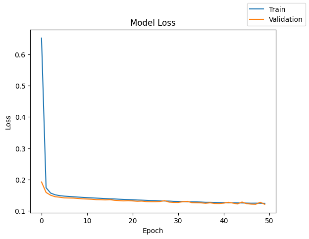

```python
plot(history_1,'loss')
```

Lets check the model performance of model_1 on training and validation data respectively.

```python
model_1_train_perf = model_performance_classification(model_1, X_train, y_train)
model_1_train_perf
```

```
469/469 ━━━━━━━━━━━━━━━━━━━━ 1s 1ms/step
```

|  | Accuracy | Recall | Precision | F1 Score |
| --- | --- | --- | --- | --- |
| 0 | 0.964133 | 0.780766 | 0.848682 | 0.81051 |

```python
model_1_val_perf = model_performance_classification(model_1, X_val, y_val)
model_1_val_perf
```

```
157/157 ━━━━━━━━━━━━━━━━━━━━ 0s 1ms/step
```

|  | Accuracy | Recall | Precision | F1 Score |
| --- | --- | --- | --- | --- |
| 0 | 0.9674 | 0.796546 | 0.868582 | 0.828095 |

```python
y_train_pred_1 = model_1.predict(X_train)
y_val_pred_1 = model_1.predict(X_val)
```

```
469/469 ━━━━━━━━━━━━━━━━━━━━ 0s 1ms/step
157/157 ━━━━━━━━━━━━━━━━━━━━ 0s 1ms/step
```

Lets check the classification report of model_1 on training and validation data respectively.

```python
print("Classification Report - Train data Model_1",end="\n\n")
cr_train_model_1 = classification_report(y_train,y_train_pred_1>0.5, zero_division=0)
print(cr_train_model_1)
```

```
Classification Report - Train data Model_1

              precision    recall  f1-score   support

         0.0       0.98      0.99      0.98     14168
         1.0       0.72      0.57      0.64       832

    accuracy                           0.96     15000
   macro avg       0.85      0.78      0.81     15000
weighted avg       0.96      0.96      0.96     15000
```

```python
print("Classification Report – Validation data Model_1", end="\n\n")
cr_val_model_1 = classification_report(y_val, (y_val_pred_1 > 0.5).astype("int"), zero_division=0)
print(cr_val_model_1)
```

```
Classification Report – Validation data Model_1

              precision    recall  f1-score   support

         0.0       0.98      0.99      0.98      4722
         1.0       0.76      0.60      0.67       278

    accuracy                           0.97      5000
   macro avg       0.87      0.80      0.83      5000
weighted avg       0.96      0.97      0.97      5000
```

### 🔍 Model 1 Insight (Best Model)

Model 1 outperformed all others with an F1 Score of 0.828 on the validation set. Its architecture (64 → 32 → 1) combined with a finely tuned SGD optimizer (lr = 0.0005) yielded the most stable and generalizable result. It demonstrated strong recall and precision without overfitting.

This is the recommended model for deployment.

## Model 2

To introduce Regularization in our model, let's set the dropout to 50% after adding the first hidden layer. This step will randomly drop 50% of the neurons before proceeding to the next layer, reducing overfitting.

```python
# clears the current Keras session, resetting all layers and models previously created, freeing up memory and resources.
tf.keras.backend.clear_session()
```

```python
model_2 = Sequential()
model_2.add(Dense(64, activation="relu", kernel_initializer='he_uniform', input_dim=X_train.shape[1]))
model_2.add(Dropout(0.5))  # Dropout del 50%
model_2.add(Dense(32, activation="relu"))
model_2.add(Dense(16, activation="relu"))
model_2.add(Dense(1, activation="sigmoid"))
```

```python
model_2.summary()
```

```
Model: "sequential"
```

```
┏━━━━━━━━━━━━━━━━━━━━━━━━━━━━━━━━━┳━━━━━━━━━━━━━━━━━━━━━━━━┳━━━━━━━━━━━━━━━┓
┃ Layer (type)                    ┃ Output Shape           ┃       Param # ┃
┡━━━━━━━━━━━━━━━━━━━━━━━━━━━━━━━━━╇━━━━━━━━━━━━━━━━━━━━━━━━╇━━━━━━━━━━━━━━━┩
│ dense (Dense)                   │ (None, 64)             │         2,624 │
├─────────────────────────────────┼────────────────────────┼───────────────┤
│ dropout (Dropout)               │ (None, 64)             │             0 │
├─────────────────────────────────┼────────────────────────┼───────────────┤
│ dense_1 (Dense)                 │ (None, 32)             │         2,080 │
├─────────────────────────────────┼────────────────────────┼───────────────┤
│ dense_2 (Dense)                 │ (None, 16)             │           528 │
├─────────────────────────────────┼────────────────────────┼───────────────┤
│ dense_3 (Dense)                 │ (None, 1)              │            17 │
└─────────────────────────────────┴────────────────────────┴───────────────┘
```

```
 Total params: 5,249 (20.50 KB)
```

```
 Trainable params: 5,249 (20.50 KB)
```

```
 Non-trainable params: 0 (0.00 B)
```

```python
optimizer = tf.keras.optimizers.SGD(learning_rate=0.001)
model_2.compile(optimizer=optimizer, loss='binary_crossentropy', metrics=['Recall'])
early_stop = EarlyStopping(monitor='val_loss', patience=7, restore_best_weights=True)
```

```python
start = time.time()
history_2 = model_2.fit(X_train, y_train, validation_data=(X_val,y_val) , batch_size=(batch_size), epochs=(epochs+50), callbacks=[early_stop])
end=time.time()
```

```
469/469 ━━━━━━━━━━━━━━━━━━━━ 4s 7ms/step - Recall: 0.5575 - loss: 1.7433 - val_Recall: 0.6295 - val_loss: 0.1721
469/469 ━━━━━━━━━━━━━━━━━━━━ 3s 6ms/step - Recall: 0.5846 - loss: 0.3396 - val_Recall: 0.6259 - val_loss: 0.1549
469/469 ━━━━━━━━━━━━━━━━━━━━ 3s 6ms/step - Recall: 0.5849 - loss: 0.2690 - val_Recall: 0.6295 - val_loss: 0.1536
469/469 ━━━━━━━━━━━━━━━━━━━━ 3s 6ms/step - Recall: 0.5670 - loss: 0.2393 - val_Recall: 0.6223 - val_loss: 0.1509
469/469 ━━━━━━━━━━━━━━━━━━━━ 3s 7ms/step - Recall: 0.5436 - loss: 0.2283 - val_Recall: 0.6151 - val_loss: 0.1481
469/469 ━━━━━━━━━━━━━━━━━━━━ 3s 7ms/step - Recall: 0.5738 - loss: 0.2144 - val_Recall: 0.6151 - val_loss: 0.1485
469/469 ━━━━━━━━━━━━━━━━━━━━ 3s 6ms/step - Recall: 0.5485 - loss: 0.2135 - val_Recall: 0.6043 - val_loss: 0.1452
469/469 ━━━━━━━━━━━━━━━━━━━━ 3s 7ms/step - Recall: 0.5801 - loss: 0.1910 - val_Recall: 0.6043 - val_loss: 0.1436
469/469 ━━━━━━━━━━━━━━━━━━━━ 3s 7ms/step - Recall: 0.5225 - loss: 0.2028 - val_Recall: 0.5755 - val_loss: 0.1416
469/469 ━━━━━━━━━━━━━━━━━━━━ 3s 6ms/step - Recall: 0.5419 - loss: 0.1991 - val_Recall: 0.5647 - val_loss: 0.1396
469/469 ━━━━━━━━━━━━━━━━━━━━ 3s 7ms/step - Recall: 0.5075 - loss: 0.1932 - val_Recall: 0.5612 - val_loss: 0.1390
469/469 ━━━━━━━━━━━━━━━━━━━━ 3s 7ms/step - Recall: 0.5281 - loss: 0.1837 - val_Recall: 0.5540 - val_loss: 0.1376
469/469 ━━━━━━━━━━━━━━━━━━━━ 3s 7ms/step - Recall: 0.5443 - loss: 0.1780 - val_Recall: 0.5576 - val_loss: 0.1360
469/469 ━━━━━━━━━━━━━━━━━━━━ 3s 7ms/step - Recall: 0.5334 - loss: 0.1649 - val_Recall: 0.5612 - val_loss: 0.1365
469/469 ━━━━━━━━━━━━━━━━━━━━ 3s 7ms/step - Recall: 0.5286 - loss: 0.1737 - val_Recall: 0.5432 - val_loss: 0.1330
469/469 ━━━━━━━━━━━━━━━━━━━━ 3s 7ms/step - Recall: 0.5521 - loss: 0.1690 - val_Recall: 0.5504 - val_loss: 0.1333
469/469 ━━━━━━━━━━━━━━━━━━━━ 3s 7ms/step - Recall: 0.5176 - loss: 0.1641 - val_Recall: 0.5432 - val_loss: 0.1318
469/469 ━━━━━━━━━━━━━━━━━━━━ 3s 7ms/step - Recall: 0.4800 - loss: 0.1702 - val_Recall: 0.5252 - val_loss: 0.1297
469/469 ━━━━━━━━━━━━━━━━━━━━ 3s 6ms/step - Recall: 0.5014 - loss: 0.1605 - val_Recall: 0.5324 - val_loss: 0.1287
469/469 ━━━━━━━━━━━━━━━━━━━━ 3s 7ms/step - Recall: 0.4725 - loss: 0.1642 - val_Recall: 0.5288 - val_loss: 0.1274
469/469 ━━━━━━━━━━━━━━━━━━━━ 3s 7ms/step - Recall: 0.4949 - loss: 0.1639 - val_Recall: 0.5324 - val_loss: 0.1264
469/469 ━━━━━━━━━━━━━━━━━━━━ 3s 7ms/step - Recall: 0.5007 - loss: 0.1542 - val_Recall: 0.5108 - val_loss: 0.1262
469/469 ━━━━━━━━━━━━━━━━━━━━ 3s 7ms/step - Recall: 0.4746 - loss: 0.1617 - val_Recall: 0.5216 - val_loss: 0.1266
469/469 ━━━━━━━━━━━━━━━━━━━━ 3s 7ms/step - Recall: 0.5008 - loss: 0.1589 - val_Recall: 0.5108 - val_loss: 0.1252
469/469 ━━━━━━━━━━━━━━━━━━━━ 3s 7ms/step - Recall: 0.5023 - loss: 0.1501 - val_Recall: 0.4964 - val_loss: 0.1249
469/469 ━━━━━━━━━━━━━━━━━━━━ 3s 6ms/step - Recall: 0.4684 - loss: 0.1572 - val_Recall: 0.5072 - val_loss: 0.1236
469/469 ━━━━━━━━━━━━━━━━━━━━ 3s 7ms/step - Recall: 0.4820 - loss: 0.1513 - val_Recall: 0.4964 - val_loss: 0.1233
469/469 ━━━━━━━━━━━━━━━━━━━━ 3s 7ms/step - Recall: 0.4513 - loss: 0.1585 - val_Recall: 0.5036 - val_loss: 0.1224
469/469 ━━━━━━━━━━━━━━━━━━━━ 3s 6ms/step - Recall: 0.4686 - loss: 0.1450 - val_Recall: 0.4856 - val_loss: 0.1218
469/469 ━━━━━━━━━━━━━━━━━━━━ 3s 7ms/step - Recall: 0.4658 - loss: 0.1511 - val_Recall: 0.5000 - val_loss: 0.1229
469/469 ━━━━━━━━━━━━━━━━━━━━ 3s 7ms/step - Recall: 0.4597 - loss: 0.1561 - val_Recall: 0.4712 - val_loss: 0.1209
469/469 ━━━━━━━━━━━━━━━━━━━━ 3s 6ms/step - Recall: 0.4362 - loss: 0.1500 - val_Recall: 0.4820 - val_loss: 0.1203
469/469 ━━━━━━━━━━━━━━━━━━━━ 3s 7ms/step - Recall: 0.4871 - loss: 0.1447 - val_Recall: 0.4676 - val_loss: 0.1204
469/469 ━━━━━━━━━━━━━━━━━━━━ 3s 7ms/step - Recall: 0.4616 - loss: 0.1434 - val_Recall: 0.4604 - val_loss: 0.1201
469/469 ━━━━━━━━━━━━━━━━━━━━ 3s 6ms/step - Recall: 0.4378 - loss: 0.1501 - val_Recall: 0.4748 - val_loss: 0.1202
469/469 ━━━━━━━━━━━━━━━━━━━━ 3s 7ms/step - Recall: 0.4625 - loss: 0.1426 - val_Recall: 0.4604 - val_loss: 0.1202
469/469 ━━━━━━━━━━━━━━━━━━━━ 3s 7ms/step - Recall: 0.4671 - loss: 0.1414 - val_Recall: 0.4712 - val_loss: 0.1212
469/469 ━━━━━━━━━━━━━━━━━━━━ 3s 7ms/step - Recall: 0.4514 - loss: 0.1415 - val_Recall: 0.4640 - val_loss: 0.1197
469/469 ━━━━━━━━━━━━━━━━━━━━ 3s 7ms/step - Recall: 0.4809 - loss: 0.1370 - val_Recall: 0.4496 - val_loss: 0.1184
469/469 ━━━━━━━━━━━━━━━━━━━━ 3s 7ms/step - Recall: 0.4715 - loss: 0.1385 - val_Recall: 0.4496 - val_loss: 0.1187
469/469 ━━━━━━━━━━━━━━━━━━━━ 3s 7ms/step - Recall: 0.4506 - loss: 0.1425 - val_Recall: 0.4532 - val_loss: 0.1183
469/469 ━━━━━━━━━━━━━━━━━━━━ 3s 6ms/step - Recall: 0.4275 - loss: 0.1443 - val_Recall: 0.4424 - val_loss: 0.1193
469/469 ━━━━━━━━━━━━━━━━━━━━ 4s 8ms/step - Recall: 0.4496 - loss: 0.1441 - val_Recall: 0.4245 - val_loss: 0.1187
469/469 ━━━━━━━━━━━━━━━━━━━━ 3s 7ms/step - Recall: 0.4263 - loss: 0.1357 - val_Recall: 0.4460 - val_loss: 0.1168
469/469 ━━━━━━━━━━━━━━━━━━━━ 3s 6ms/step - Recall: 0.4785 - loss: 0.1362 - val_Recall: 0.4424 - val_loss: 0.1170
469/469 ━━━━━━━━━━━━━━━━━━━━ 4s 8ms/step - Recall: 0.4134 - loss: 0.1426 - val_Recall: 0.4424 - val_loss: 0.1176
469/469 ━━━━━━━━━━━━━━━━━━━━ 3s 7ms/step - Recall: 0.4099 - loss: 0.1453 - val_Recall: 0.4209 - val_loss: 0.1173
469/469 ━━━━━━━━━━━━━━━━━━━━ 3s 6ms/step - Recall: 0.4333 - loss: 0.1408 - val_Recall: 0.4676 - val_loss: 0.1185
469/469 ━━━━━━━━━━━━━━━━━━━━ 3s 7ms/step - Recall: 0.4664 - loss: 0.1350 - val_Recall: 0.4137 - val_loss: 0.1177
469/469 ━━━━━━━━━━━━━━━━━━━━ 3s 7ms/step - Recall: 0.3985 - loss: 0.1434 - val_Recall: 0.4173 - val_loss: 0.1173
469/469 ━━━━━━━━━━━━━━━━━━━━ 3s 7ms/step - Recall: 0.4780 - loss: 0.1251 - val_Recall: 0.4137 - val_loss: 0.1169
```

```python
print("Time taken in seconds ",end-start)
```

```
Time taken in seconds  161.78556180000305
```

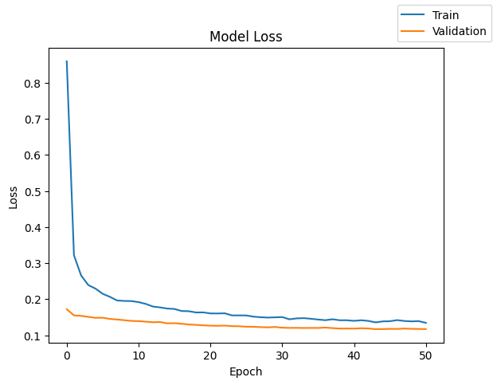

```python
plot(history_2,'loss')
```

Lets check the model performance of model_2 on training and validation data respectively.

```python
model_2_train_perf = model_performance_classification(model_2, X_train, y_train)
model_2_train_perf
```

```
469/469 ━━━━━━━━━━━━━━━━━━━━ 1s 1ms/step
```

|  | Accuracy | Recall | Precision | F1 Score |
| --- | --- | --- | --- | --- |
| 0 | 0.966333 | 0.724232 | 0.92671 | 0.79034 |

```python
model_2_val_perf = model_performance_classification(model_2, X_val, y_val)
model_2_val_perf
```

```
157/157 ━━━━━━━━━━━━━━━━━━━━ 0s 947us/step
```

|  | Accuracy | Recall | Precision | F1 Score |
| --- | --- | --- | --- | --- |
| 0 | 0.9656 | 0.721116 | 0.92077 | 0.786261 |

```python
y_train_pred_2 = model_2.predict(X_train)
y_val_pred_2 = model_2.predict(X_val)
```

```
469/469 ━━━━━━━━━━━━━━━━━━━━ 0s 960us/step
157/157 ━━━━━━━━━━━━━━━━━━━━ 0s 1ms/step
```

Lets check the classification report of model_2 on training and validation data respectively.

```python
print("Classification Report - Train data Model_1",end="\n\n")
cr_train_model_2 = classification_report(y_train,y_train_pred_2>0.5, zero_division=0)
print(cr_train_model_2)
```

```
Classification Report - Train data Model_1

              precision    recall  f1-score   support

         0.0       0.97      1.00      0.98     14168
         1.0       0.88      0.45      0.60       832

    accuracy                           0.97     15000
   macro avg       0.93      0.72      0.79     15000
weighted avg       0.96      0.97      0.96     15000
```

```python
print("Classification Report – Validation data Model_1", end="\n\n")
cr_val_model_2 = classification_report(y_val, (y_val_pred_2 > 0.5).astype("int"), zero_division=0)
print(cr_val_model_2)
```

```
Classification Report – Validation data Model_1

              precision    recall  f1-score   support

         0.0       0.97      1.00      0.98      4722
         1.0       0.87      0.45      0.59       278

    accuracy                           0.97      5000
   macro avg       0.92      0.72      0.79      5000
weighted avg       0.96      0.97      0.96      5000
```

### 🔍 Model 2 Insight

Model 2 introduced deeper layers and Dropout(0.5), which slightly limited learning. It achieved excellent precision (0.92), but slightly lower recall. It is ideal when false positives are expensive, though it underperformed compared to Model 1 in balanced F1.

## Model 3

As we have are dealing with an imbalance in class distribution, we should also be using class weights to allow the model to give proportionally more importance to the minority class.

```python
# clears the current Keras session, resetting all layers and models previously created, freeing up memory and resources.
tf.keras.backend.clear_session()
```

```python
cw = class_weight.compute_class_weight(class_weight='balanced', classes=np.unique(y_train), y=y_train)
cw_dict = {i: cw[i] for i in range(len(cw))}
```

```python
model_3 = Sequential()
model_3.add(Dense(64, activation="relu", kernel_initializer='he_uniform', input_dim=X_train.shape[1]))
model_3.add(Dropout(0.5))
model_3.add(Dense(32, activation="relu"))
model_3.add(Dense(16, activation="relu"))
model_3.add(Dense(1, activation="sigmoid"))
```

```python
model_3.summary()
```

```
Model: "sequential"
```

```
┏━━━━━━━━━━━━━━━━━━━━━━━━━━━━━━━━━┳━━━━━━━━━━━━━━━━━━━━━━━━┳━━━━━━━━━━━━━━━┓
┃ Layer (type)                    ┃ Output Shape           ┃       Param # ┃
┡━━━━━━━━━━━━━━━━━━━━━━━━━━━━━━━━━╇━━━━━━━━━━━━━━━━━━━━━━━━╇━━━━━━━━━━━━━━━┩
│ dense (Dense)                   │ (None, 64)             │         2,624 │
├─────────────────────────────────┼────────────────────────┼───────────────┤
│ dropout (Dropout)               │ (None, 64)             │             0 │
├─────────────────────────────────┼────────────────────────┼───────────────┤
│ dense_1 (Dense)                 │ (None, 32)             │         2,080 │
├─────────────────────────────────┼────────────────────────┼───────────────┤
│ dense_2 (Dense)                 │ (None, 16)             │           528 │
├─────────────────────────────────┼────────────────────────┼───────────────┤
│ dense_3 (Dense)                 │ (None, 1)              │            17 │
└─────────────────────────────────┴────────────────────────┴───────────────┘
```

```
 Total params: 5,249 (20.50 KB)
```

```
 Trainable params: 5,249 (20.50 KB)
```

```
 Non-trainable params: 0 (0.00 B)
```

```python
optimizer = tf.keras.optimizers.SGD(learning_rate=0.001)
model_3.compile(optimizer=optimizer, loss='binary_crossentropy', metrics=['Recall'])
```

```python
start = time.time()
history_3 = model_3.fit(X_train, y_train, validation_data=(X_val,y_val) , batch_size=batch_size, epochs=epochs,class_weight=cw_dict, )
end=time.time()
```

```
469/469 ━━━━━━━━━━━━━━━━━━━━ 4s 7ms/step - Recall: 0.6423 - loss: 1.5535 - val_Recall: 0.8201 - val_loss: 0.3214
469/469 ━━━━━━━━━━━━━━━━━━━━ 3s 7ms/step - Recall: 0.7242 - loss: 0.5518 - val_Recall: 0.8129 - val_loss: 0.3323
469/469 ━━━━━━━━━━━━━━━━━━━━ 3s 7ms/step - Recall: 0.7631 - loss: 0.4746 - val_Recall: 0.7878 - val_loss: 0.3066
469/469 ━━━━━━━━━━━━━━━━━━━━ 3s 6ms/step - Recall: 0.7359 - loss: 0.4874 - val_Recall: 0.7950 - val_loss: 0.2743
469/469 ━━━━━━━━━━━━━━━━━━━━ 3s 7ms/step - Recall: 0.8101 - loss: 0.4381 - val_Recall: 0.8201 - val_loss: 0.3207
469/469 ━━━━━━━━━━━━━━━━━━━━ 3s 7ms/step - Recall: 0.7493 - loss: 0.4898 - val_Recall: 0.8273 - val_loss: 0.3292
469/469 ━━━━━━━━━━━━━━━━━━━━ 3s 7ms/step - Recall: 0.7633 - loss: 0.4645 - val_Recall: 0.8237 - val_loss: 0.3219
469/469 ━━━━━━━━━━━━━━━━━━━━ 3s 7ms/step - Recall: 0.7610 - loss: 0.4596 - val_Recall: 0.7878 - val_loss: 0.2602
469/469 ━━━━━━━━━━━━━━━━━━━━ 3s 7ms/step - Recall: 0.7407 - loss: 0.4574 - val_Recall: 0.8129 - val_loss: 0.3381
469/469 ━━━━━━━━━━━━━━━━━━━━ 3s 7ms/step - Recall: 0.8066 - loss: 0.4336 - val_Recall: 0.8237 - val_loss: 0.3594
469/469 ━━━━━━━━━━━━━━━━━━━━ 3s 7ms/step - Recall: 0.7659 - loss: 0.4701 - val_Recall: 0.8381 - val_loss: 0.4299
469/469 ━━━━━━━━━━━━━━━━━━━━ 3s 7ms/step - Recall: 0.7824 - loss: 0.4566 - val_Recall: 0.8201 - val_loss: 0.3784
469/469 ━━━━━━━━━━━━━━━━━━━━ 3s 7ms/step - Recall: 0.8083 - loss: 0.4196 - val_Recall: 0.8094 - val_loss: 0.3218
469/469 ━━━━━━━━━━━━━━━━━━━━ 3s 7ms/step - Recall: 0.7906 - loss: 0.4747 - val_Recall: 0.8309 - val_loss: 0.3510
469/469 ━━━━━━━━━━━━━━━━━━━━ 3s 7ms/step - Recall: 0.8095 - loss: 0.4254 - val_Recall: 0.7698 - val_loss: 0.2928
469/469 ━━━━━━━━━━━━━━━━━━━━ 3s 7ms/step - Recall: 0.7846 - loss: 0.4365 - val_Recall: 0.8453 - val_loss: 0.3958
469/469 ━━━━━━━━━━━━━━━━━━━━ 3s 7ms/step - Recall: 0.7686 - loss: 0.4530 - val_Recall: 0.8201 - val_loss: 0.3087
469/469 ━━━━━━━━━━━━━━━━━━━━ 3s 7ms/step - Recall: 0.7714 - loss: 0.4608 - val_Recall: 0.7842 - val_loss: 0.2838
469/469 ━━━━━━━━━━━━━━━━━━━━ 3s 7ms/step - Recall: 0.7484 - loss: 0.5483 - val_Recall: 0.7806 - val_loss: 0.2632
469/469 ━━━━━━━━━━━━━━━━━━━━ 3s 7ms/step - Recall: 0.7550 - loss: 0.5181 - val_Recall: 0.7374 - val_loss: 0.3389
469/469 ━━━━━━━━━━━━━━━━━━━━ 3s 7ms/step - Recall: 0.7558 - loss: 0.6071 - val_Recall: 0.6259 - val_loss: 0.6986
469/469 ━━━━━━━━━━━━━━━━━━━━ 3s 7ms/step - Recall: 0.7459 - loss: 0.6623 - val_Recall: 0.8381 - val_loss: 0.4452
469/469 ━━━━━━━━━━━━━━━━━━━━ 3s 7ms/step - Recall: 0.7066 - loss: 0.8341 - val_Recall: 0.7986 - val_loss: 0.2998
469/469 ━━━━━━━━━━━━━━━━━━━━ 3s 7ms/step - Recall: 0.7537 - loss: 1.0023 - val_Recall: 0.6403 - val_loss: 0.8934
469/469 ━━━━━━━━━━━━━━━━━━━━ 3s 7ms/step - Recall: 0.6920 - loss: 1.7319 - val_Recall: 0.8022 - val_loss: 0.3192
469/469 ━━━━━━━━━━━━━━━━━━━━ 3s 6ms/step - Recall: 0.6827 - loss: 2.4967 - val_Recall: 0.7518 - val_loss: 0.4325
469/469 ━━━━━━━━━━━━━━━━━━━━ 3s 7ms/step - Recall: 0.6587 - loss: 4.0645 - val_Recall: 0.6691 - val_loss: 1.2417
469/469 ━━━━━━━━━━━━━━━━━━━━ 3s 7ms/step - Recall: 0.6652 - loss: 7.5646 - val_Recall: 0.4568 - val_loss: 109.2386
469/469 ━━━━━━━━━━━━━━━━━━━━ 3s 6ms/step - Recall: 0.6596 - loss: 16.6772 - val_Recall: 0.8058 - val_loss: 3.1104
469/469 ━━━━━━━━━━━━━━━━━━━━ 3s 7ms/step - Recall: 0.6591 - loss: 52.9307 - val_Recall: 0.5863 - val_loss: 57.5238
469/469 ━━━━━━━━━━━━━━━━━━━━ 3s 7ms/step - Recall: 0.6460 - loss: 1647.8148 - val_Recall: 0.6691 - val_loss: 23.1694
469/469 ━━━━━━━━━━━━━━━━━━━━ 3s 6ms/step - Recall: 0.5683 - loss: 170.1382 - val_Recall: 0.6727 - val_loss: 10.6320
469/469 ━━━━━━━━━━━━━━━━━━━━ 3s 7ms/step - Recall: 0.6418 - loss: 38.3758 - val_Recall: 0.7374 - val_loss: 1.9937
469/469 ━━━━━━━━━━━━━━━━━━━━ 3s 7ms/step - Recall: 0.6460 - loss: 15.6680 - val_Recall: 0.7230 - val_loss: 2.0809
469/469 ━━━━━━━━━━━━━━━━━━━━ 3s 7ms/step - Recall: 0.6865 - loss: 7.6244 - val_Recall: 0.6475 - val_loss: 3.4204
469/469 ━━━━━━━━━━━━━━━━━━━━ 3s 7ms/step - Recall: 0.6773 - loss: 8.4201 - val_Recall: 0.6583 - val_loss: 2.5488
469/469 ━━━━━━━━━━━━━━━━━━━━ 3s 7ms/step - Recall: 0.6697 - loss: 8.0326 - val_Recall: 0.7806 - val_loss: 0.6209
469/469 ━━━━━━━━━━━━━━━━━━━━ 3s 7ms/step - Recall: 0.6991 - loss: 3.1550 - val_Recall: 0.5108 - val_loss: 2.5777
469/469 ━━━━━━━━━━━━━━━━━━━━ 3s 7ms/step - Recall: 0.6714 - loss: 4.1183 - val_Recall: 0.7770 - val_loss: 0.6778
469/469 ━━━━━━━━━━━━━━━━━━━━ 3s 6ms/step - Recall: 0.7110 - loss: 2.8719 - val_Recall: 0.6763 - val_loss: 0.9401
469/469 ━━━━━━━━━━━━━━━━━━━━ 3s 7ms/step - Recall: 0.6424 - loss: 4.5236 - val_Recall: 0.8309 - val_loss: 1.1718
469/469 ━━━━━━━━━━━━━━━━━━━━ 3s 7ms/step - Recall: 0.6786 - loss: 3.4941 - val_Recall: 0.6259 - val_loss: 2.4485
469/469 ━━━━━━━━━━━━━━━━━━━━ 3s 7ms/step - Recall: 0.6998 - loss: 3.9965 - val_Recall: 0.7914 - val_loss: 0.6352
469/469 ━━━━━━━━━━━━━━━━━━━━ 3s 7ms/step - Recall: 0.7299 - loss: 2.0913 - val_Recall: 0.7194 - val_loss: 0.8470
469/469 ━━━━━━━━━━━━━━━━━━━━ 3s 7ms/step - Recall: 0.6972 - loss: 2.0816 - val_Recall: 0.7482 - val_loss: 0.3093
469/469 ━━━━━━━━━━━━━━━━━━━━ 3s 7ms/step - Recall: 0.6969 - loss: 1.9491 - val_Recall: 0.6835 - val_loss: 1.3537
469/469 ━━━━━━━━━━━━━━━━━━━━ 3s 7ms/step - Recall: 0.7168 - loss: 2.0579 - val_Recall: 0.7986 - val_loss: 0.5211
469/469 ━━━━━━━━━━━━━━━━━━━━ 3s 7ms/step - Recall: 0.7021 - loss: 1.7618 - val_Recall: 0.7122 - val_loss: 0.7905
469/469 ━━━━━━━━━━━━━━━━━━━━ 3s 7ms/step - Recall: 0.7118 - loss: 2.3454 - val_Recall: 0.6511 - val_loss: 0.9539
469/469 ━━━━━━━━━━━━━━━━━━━━ 3s 7ms/step - Recall: 0.7070 - loss: 2.2143 - val_Recall: 0.6259 - val_loss: 4.2794
```

```python
print("Time taken in seconds ",end-start)
```

```
Time taken in seconds  161.3135278224945
```

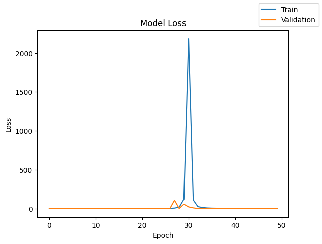

```python
plot(history_3,'loss')
```

Lets check the model performance of model_3 on training and validation data respectively.

```python
model_3_train_perf = model_performance_classification(model_3, X_train, y_train)
model_3_train_perf
```

```
469/469 ━━━━━━━━━━━━━━━━━━━━ 1s 1ms/step
```

|  | Accuracy | Recall | Precision | F1 Score |
| --- | --- | --- | --- | --- |
| 0 | 0.412333 | 0.54014 | 0.508824 | 0.33731 |

```python
model_3_val_perf = model_performance_classification(model_3, X_val, y_val)
model_3_val_perf
```

```
157/157 ━━━━━━━━━━━━━━━━━━━━ 0s 1ms/step
```

|  | Accuracy | Recall | Precision | F1 Score |
| --- | --- | --- | --- | --- |
| 0 | 0.4052 | 0.509053 | 0.501996 | 0.329707 |

```python
y_train_pred_3 = model_3.predict(X_train)
y_val_pred_3 = model_3.predict(X_val)
```

```
469/469 ━━━━━━━━━━━━━━━━━━━━ 0s 987us/step
157/157 ━━━━━━━━━━━━━━━━━━━━ 0s 1ms/step
```

Lets check the classification report of model_3 on training and validation data respectively.

```python
print("Classification Report - Train data Model_3", end="\n\n")
cr_train_model_3 = classification_report(y_train, y_train_pred_3 > 0.5, zero_division=0)
print(cr_train_model_3)
```

```
Classification Report - Train data Model_3

              precision    recall  f1-score   support

         0.0       0.96      0.40      0.56     14168
         1.0       0.06      0.68      0.11       832

    accuracy                           0.41     15000
   macro avg       0.51      0.54      0.34     15000
weighted avg       0.91      0.41      0.54     15000
```

```python
print("Classification Report - Validation data Model_3", end="\n\n")
cr_val_model_3 = classification_report(y_val, y_val_pred_3 > 0.5, zero_division=0)
print(cr_val_model_3)
```

```
Classification Report - Validation data Model_3

              precision    recall  f1-score   support

         0.0       0.95      0.39      0.55      4722
         1.0       0.06      0.63      0.10       278

    accuracy                           0.41      5000
   macro avg       0.50      0.51      0.33      5000
weighted avg       0.90      0.41      0.53      5000
```

### 🔍 Model 3 Insight

Despite adding class weights to the same architecture as Model 2, performance dropped significantly. The combination of `class_weight`, dropout, and SGD likely caused over-regularization. This model underperformed across all metrics and should be restructured.

## Model 4

Since we have used only SGD optimizer till now, let's use another kind of optimizer and observe its impact on the model performmance.

```python
# clears the current Keras session, resetting all layers and models previously created, freeing up memory and resources.
tf.keras.backend.clear_session()
```

```python
model_4 = Sequential()
model_4.add(Dense(64, activation="relu", kernel_initializer='he_uniform', input_dim=X_train.shape[1]))
model_4.add(Dense(32, activation="relu"))
model_4.add(Dense(1, activation="sigmoid"))
```

```python
model_4.summary()
```

```
Model: "sequential"
```

```
┏━━━━━━━━━━━━━━━━━━━━━━━━━━━━━━━━━┳━━━━━━━━━━━━━━━━━━━━━━━━┳━━━━━━━━━━━━━━━┓
┃ Layer (type)                    ┃ Output Shape           ┃       Param # ┃
┡━━━━━━━━━━━━━━━━━━━━━━━━━━━━━━━━━╇━━━━━━━━━━━━━━━━━━━━━━━━╇━━━━━━━━━━━━━━━┩
│ dense (Dense)                   │ (None, 64)             │         2,624 │
├─────────────────────────────────┼────────────────────────┼───────────────┤
│ dense_1 (Dense)                 │ (None, 32)             │         2,080 │
├─────────────────────────────────┼────────────────────────┼───────────────┤
│ dense_2 (Dense)                 │ (None, 1)              │            33 │
└─────────────────────────────────┴────────────────────────┴───────────────┘
```

```
 Total params: 4,737 (18.50 KB)
```

```
 Trainable params: 4,737 (18.50 KB)
```

```
 Non-trainable params: 0 (0.00 B)
```

```python
optimizer = tf.keras.optimizers.Adam(learning_rate=0.001)
model_4.compile(optimizer=optimizer, loss='binary_crossentropy', metrics=['Recall'])
```

```python
start = time.time()
history_4 = model_4.fit(X_train, y_train, validation_data=(X_val,y_val) , batch_size=batch_size, epochs=epochs)
end=time.time()
```

```
469/469 ━━━━━━━━━━━━━━━━━━━━ 6s 10ms/step - Recall: 0.5932 - loss: 0.3019 - val_Recall: 0.5288 - val_loss: 0.1238
469/469 ━━━━━━━━━━━━━━━━━━━━ 4s 9ms/step - Recall: 0.5367 - loss: 0.1451 - val_Recall: 0.5144 - val_loss: 0.1698
469/469 ━━━━━━━━━━━━━━━━━━━━ 4s 10ms/step - Recall: 0.4879 - loss: 0.1747 - val_Recall: 0.4784 - val_loss: 0.3238
469/469 ━━━━━━━━━━━━━━━━━━━━ 4s 9ms/step - Recall: 0.5066 - loss: 0.2230 - val_Recall: 0.4712 - val_loss: 0.5421
469/469 ━━━━━━━━━━━━━━━━━━━━ 4s 9ms/step - Recall: 0.4816 - loss: 0.3252 - val_Recall: 0.4388 - val_loss: 0.2994
469/469 ━━━━━━━━━━━━━━━━━━━━ 4s 9ms/step - Recall: 0.5206 - loss: 0.4675 - val_Recall: 0.5468 - val_loss: 0.2340
469/469 ━━━━━━━━━━━━━━━━━━━━ 4s 9ms/step - Recall: 0.5076 - loss: 0.5827 - val_Recall: 0.5000 - val_loss: 0.4602
469/469 ━━━━━━━━━━━━━━━━━━━━ 5s 10ms/step - Recall: 0.5327 - loss: 0.5043 - val_Recall: 0.5216 - val_loss: 2.5265
469/469 ━━━━━━━━━━━━━━━━━━━━ 4s 9ms/step - Recall: 0.5084 - loss: 0.9928 - val_Recall: 0.5144 - val_loss: 0.7234
469/469 ━━━━━━━━━━━━━━━━━━━━ 4s 9ms/step - Recall: 0.4982 - loss: 1.0705 - val_Recall: 0.5540 - val_loss: 0.6276
469/469 ━━━━━━━━━━━━━━━━━━━━ 4s 9ms/step - Recall: 0.5001 - loss: 1.3453 - val_Recall: 0.5755 - val_loss: 0.5632
469/469 ━━━━━━━━━━━━━━━━━━━━ 4s 9ms/step - Recall: 0.5065 - loss: 1.5531 - val_Recall: 0.5396 - val_loss: 0.9084
469/469 ━━━━━━━━━━━━━━━━━━━━ 4s 9ms/step - Recall: 0.5455 - loss: 1.7200 - val_Recall: 0.4604 - val_loss: 1.1875
469/469 ━━━━━━━━━━━━━━━━━━━━ 4s 9ms/step - Recall: 0.5024 - loss: 1.9684 - val_Recall: 0.5360 - val_loss: 5.5545
469/469 ━━━━━━━━━━━━━━━━━━━━ 5s 10ms/step - Recall: 0.5305 - loss: 2.0615 - val_Recall: 0.4784 - val_loss: 1.0940
469/469 ━━━━━━━━━━━━━━━━━━━━ 4s 9ms/step - Recall: 0.4788 - loss: 2.3728 - val_Recall: 0.4964 - val_loss: 1.7859
469/469 ━━━━━━━━━━━━━━━━━━━━ 5s 10ms/step - Recall: 0.5321 - loss: 2.2284 - val_Recall: 0.5899 - val_loss: 1.1714
469/469 ━━━━━━━━━━━━━━━━━━━━ 4s 9ms/step - Recall: 0.5035 - loss: 2.4236 - val_Recall: 0.5396 - val_loss: 1.3184
469/469 ━━━━━━━━━━━━━━━━━━━━ 5s 10ms/step - Recall: 0.5256 - loss: 3.0923 - val_Recall: 0.5108 - val_loss: 1.5662
469/469 ━━━━━━━━━━━━━━━━━━━━ 4s 9ms/step - Recall: 0.4808 - loss: 2.5103 - val_Recall: 0.4496 - val_loss: 4.1615
469/469 ━━━━━━━━━━━━━━━━━━━━ 4s 9ms/step - Recall: 0.4913 - loss: 4.8653 - val_Recall: 0.5216 - val_loss: 3.0135
469/469 ━━━━━━━━━━━━━━━━━━━━ 4s 9ms/step - Recall: 0.4824 - loss: 5.2316 - val_Recall: 0.6799 - val_loss: 2.1816
469/469 ━━━━━━━━━━━━━━━━━━━━ 4s 9ms/step - Recall: 0.5468 - loss: 4.0539 - val_Recall: 0.5288 - val_loss: 2.3400
469/469 ━━━━━━━━━━━━━━━━━━━━ 4s 9ms/step - Recall: 0.5395 - loss: 3.9115 - val_Recall: 0.5000 - val_loss: 13.9034
469/469 ━━━━━━━━━━━━━━━━━━━━ 4s 9ms/step - Recall: 0.4907 - loss: 5.3035 - val_Recall: 0.4388 - val_loss: 5.1461
469/469 ━━━━━━━━━━━━━━━━━━━━ 4s 9ms/step - Recall: 0.4687 - loss: 5.7658 - val_Recall: 0.4353 - val_loss: 3.7389
469/469 ━━━━━━━━━━━━━━━━━━━━ 4s 9ms/step - Recall: 0.4612 - loss: 7.3582 - val_Recall: 0.4640 - val_loss: 14.3543
469/469 ━━━━━━━━━━━━━━━━━━━━ 4s 9ms/step - Recall: 0.4965 - loss: 5.6519 - val_Recall: 0.5971 - val_loss: 3.0381
469/469 ━━━━━━━━━━━━━━━━━━━━ 4s 9ms/step - Recall: 0.4940 - loss: 5.4119 - val_Recall: 0.5647 - val_loss: 2.8086
469/469 ━━━━━━━━━━━━━━━━━━━━ 4s 9ms/step - Recall: 0.5430 - loss: 3.7089 - val_Recall: 0.6187 - val_loss: 3.6040
469/469 ━━━━━━━━━━━━━━━━━━━━ 4s 10ms/step - Recall: 0.5293 - loss: 5.3870 - val_Recall: 0.4964 - val_loss: 11.5095
469/469 ━━━━━━━━━━━━━━━━━━━━ 4s 9ms/step - Recall: 0.4758 - loss: 6.7950 - val_Recall: 0.4676 - val_loss: 4.5190
469/469 ━━━━━━━━━━━━━━━━━━━━ 4s 9ms/step - Recall: 0.5286 - loss: 5.8330 - val_Recall: 0.5144 - val_loss: 31.1625
469/469 ━━━━━━━━━━━━━━━━━━━━ 4s 9ms/step - Recall: 0.5308 - loss: 7.7168 - val_Recall: 0.4856 - val_loss: 10.4767
469/469 ━━━━━━━━━━━━━━━━━━━━ 4s 9ms/step - Recall: 0.5270 - loss: 8.6412 - val_Recall: 0.4820 - val_loss: 9.9493
469/469 ━━━━━━━━━━━━━━━━━━━━ 4s 9ms/step - Recall: 0.5049 - loss: 8.0196 - val_Recall: 0.5216 - val_loss: 7.5046
469/469 ━━━━━━━━━━━━━━━━━━━━ 4s 9ms/step - Recall: 0.4928 - loss: 10.3978 - val_Recall: 0.5504 - val_loss: 5.3836
469/469 ━━━━━━━━━━━━━━━━━━━━ 4s 9ms/step - Recall: 0.4795 - loss: 10.2711 - val_Recall: 0.5468 - val_loss: 4.5572
469/469 ━━━━━━━━━━━━━━━━━━━━ 4s 9ms/step - Recall: 0.5156 - loss: 7.3228 - val_Recall: 0.4424 - val_loss: 23.6035
469/469 ━━━━━━━━━━━━━━━━━━━━ 4s 9ms/step - Recall: 0.5259 - loss: 7.9882 - val_Recall: 0.5683 - val_loss: 4.7558
469/469 ━━━━━━━━━━━━━━━━━━━━ 4s 9ms/step - Recall: 0.5449 - loss: 9.9623 - val_Recall: 0.6295 - val_loss: 5.3075
469/469 ━━━━━━━━━━━━━━━━━━━━ 4s 9ms/step - Recall: 0.4999 - loss: 11.0739 - val_Recall: 0.6115 - val_loss: 5.0879
469/469 ━━━━━━━━━━━━━━━━━━━━ 5s 10ms/step - Recall: 0.5047 - loss: 10.8692 - val_Recall: 0.4676 - val_loss: 8.4106
469/469 ━━━━━━━━━━━━━━━━━━━━ 4s 9ms/step - Recall: 0.5437 - loss: 12.3722 - val_Recall: 0.5216 - val_loss: 19.5673
469/469 ━━━━━━━━━━━━━━━━━━━━ 5s 10ms/step - Recall: 0.5353 - loss: 9.7458 - val_Recall: 0.5288 - val_loss: 4.6914
469/469 ━━━━━━━━━━━━━━━━━━━━ 4s 9ms/step - Recall: 0.4827 - loss: 16.8347 - val_Recall: 0.5360 - val_loss: 11.5982
469/469 ━━━━━━━━━━━━━━━━━━━━ 4s 9ms/step - Recall: 0.5082 - loss: 9.1967 - val_Recall: 0.4532 - val_loss: 7.3707
469/469 ━━━━━━━━━━━━━━━━━━━━ 4s 9ms/step - Recall: 0.4699 - loss: 11.9719 - val_Recall: 0.5863 - val_loss: 8.2271
469/469 ━━━━━━━━━━━━━━━━━━━━ 4s 9ms/step - Recall: 0.4718 - loss: 14.1457 - val_Recall: 0.4245 - val_loss: 15.0418
469/469 ━━━━━━━━━━━━━━━━━━━━ 4s 9ms/step - Recall: 0.4960 - loss: 14.2107 - val_Recall: 0.5216 - val_loss: 10.3532
```

```python
print("Time taken in seconds ",end-start)
```

```
Time taken in seconds  217.4669418334961
```

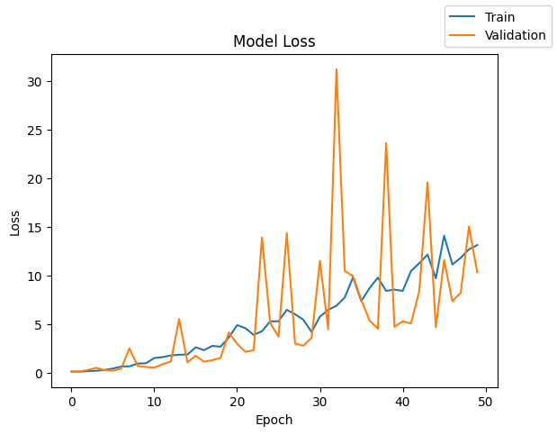

```python
plot(history_4,'loss')
```

Lets check the model performance ofr model_4 on training and validation data respectively

```python
model_4_train_perf = model_performance_classification(model_4, X_train, y_train)
model_4_train_perf
```

```
469/469 ━━━━━━━━━━━━━━━━━━━━ 1s 1ms/step
```

|  | Accuracy | Recall | Precision | F1 Score |
| --- | --- | --- | --- | --- |
| 0 | 0.939533 | 0.732107 | 0.714489 | 0.722872 |

```python
model_4_val_perf = model_performance_classification(model_4, X_val, y_val)
model_4_val_perf
```

```
157/157 ━━━━━━━━━━━━━━━━━━━━ 0s 1ms/step
```

|  | Accuracy | Recall | Precision | F1 Score |
| --- | --- | --- | --- | --- |
| 0 | 0.9392 | 0.742685 | 0.715233 | 0.727948 |

```python
y_train_pred_4 = model_4.predict(X_train)
y_val_pred_4 = model_4.predict(X_val)
```

```
469/469 ━━━━━━━━━━━━━━━━━━━━ 0s 876us/step
157/157 ━━━━━━━━━━━━━━━━━━━━ 0s 997us/step
```

Lets check the classification report of model_4 on raining and validation data respectively.

```python
print("Classification Report - Train data Model_3", end="\n\n")
cr_train_model_4 = classification_report(y_train, y_train_pred_4 > 0.5, zero_division=0)
print(cr_train_model_4)
```

```
Classification Report - Train data Model_3

              precision    recall  f1-score   support

         0.0       0.97      0.97      0.97     14168
         1.0       0.46      0.50      0.48       832

    accuracy                           0.94     15000
   macro avg       0.71      0.73      0.72     15000
weighted avg       0.94      0.94      0.94     15000
```

```python
print("Classification Report - Validation data Model_3", end="\n\n")
cr_val_model_4 = classification_report(y_val, y_val_pred_4 > 0.5, zero_division=0)
print(cr_val_model_4)
```

```
Classification Report - Validation data Model_3

              precision    recall  f1-score   support

         0.0       0.97      0.96      0.97      4722
         1.0       0.46      0.52      0.49       278

    accuracy                           0.94      5000
   macro avg       0.72      0.74      0.73      5000
weighted avg       0.94      0.94      0.94      5000
```

## Model 5

This time we will add more layers and dropout while using a different optimizer.

```python
# clears the current Keras session, resetting all layers and models previously created, freeing up memory and resources.
tf.keras.backend.clear_session()
```

```python
model_5 = Sequential()
model_5.add(Dense(64, activation="relu", kernel_initializer='he_uniform', input_dim=X_train.shape[1]))
model_5.add(Dropout(0.5))
model_5.add(Dense(32, activation="relu"))
model_5.add(Dense(16, activation="relu"))
model_5.add(Dense(1, activation="sigmoid"))
```

```python
model_5.summary()
```

```
Model: "sequential"
```

```
┏━━━━━━━━━━━━━━━━━━━━━━━━━━━━━━━━━┳━━━━━━━━━━━━━━━━━━━━━━━━┳━━━━━━━━━━━━━━━┓
┃ Layer (type)                    ┃ Output Shape           ┃       Param # ┃
┡━━━━━━━━━━━━━━━━━━━━━━━━━━━━━━━━━╇━━━━━━━━━━━━━━━━━━━━━━━━╇━━━━━━━━━━━━━━━┩
│ dense (Dense)                   │ (None, 64)             │         2,624 │
├─────────────────────────────────┼────────────────────────┼───────────────┤
│ dropout (Dropout)               │ (None, 64)             │             0 │
├─────────────────────────────────┼────────────────────────┼───────────────┤
│ dense_1 (Dense)                 │ (None, 32)             │         2,080 │
├─────────────────────────────────┼────────────────────────┼───────────────┤
│ dense_2 (Dense)                 │ (None, 16)             │           528 │
├─────────────────────────────────┼────────────────────────┼───────────────┤
│ dense_3 (Dense)                 │ (None, 1)              │            17 │
└─────────────────────────────────┴────────────────────────┴───────────────┘
```

```
 Total params: 5,249 (20.50 KB)
```

```
 Trainable params: 5,249 (20.50 KB)
```

```
 Non-trainable params: 0 (0.00 B)
```

```python
optimizer = tf.keras.optimizers.Adam(learning_rate=0.001)
model_5.compile(optimizer=optimizer, loss='binary_crossentropy', metrics=['Recall'])
```

```python
start = time.time()
history_5 = model_5.fit(X_train, y_train, validation_data=(X_val,y_val) , batch_size=batch_size, epochs=epochs)
end=time.time()
```

```
469/469 ━━━━━━━━━━━━━━━━━━━━ 6s 11ms/step - Recall: 0.5303 - loss: 0.7774 - val_Recall: 0.4424 - val_loss: 0.1404
469/469 ━━━━━━━━━━━━━━━━━━━━ 5s 12ms/step - Recall: 0.4855 - loss: 0.8295 - val_Recall: 0.6187 - val_loss: 42.9099
469/469 ━━━━━━━━━━━━━━━━━━━━ 5s 11ms/step - Recall: 0.5447 - loss: 16.2846 - val_Recall: 0.5180 - val_loss: 11.5028
469/469 ━━━━━━━━━━━━━━━━━━━━ 5s 12ms/step - Recall: 0.5131 - loss: 52.2265 - val_Recall: 0.5755 - val_loss: 6.4714
469/469 ━━━━━━━━━━━━━━━━━━━━ 5s 11ms/step - Recall: 0.5488 - loss: 92.4047 - val_Recall: 0.5612 - val_loss: 19.3534
469/469 ━━━━━━━━━━━━━━━━━━━━ 5s 11ms/step - Recall: 0.5437 - loss: 158.9533 - val_Recall: 0.6007 - val_loss: 61.6804
469/469 ━━━━━━━━━━━━━━━━━━━━ 5s 11ms/step - Recall: 0.5708 - loss: 301.6967 - val_Recall: 0.6187 - val_loss: 135.5018
469/469 ━━━━━━━━━━━━━━━━━━━━ 5s 11ms/step - Recall: 0.5233 - loss: 400.3270 - val_Recall: 0.6079 - val_loss: 125.2008
469/469 ━━━━━━━━━━━━━━━━━━━━ 5s 11ms/step - Recall: 0.5078 - loss: 429.3824 - val_Recall: 0.5971 - val_loss: 69.0020
469/469 ━━━━━━━━━━━━━━━━━━━━ 5s 11ms/step - Recall: 0.5266 - loss: 831.2465 - val_Recall: 0.4029 - val_loss: 2416.3423
469/469 ━━━━━━━━━━━━━━━━━━━━ 5s 11ms/step - Recall: 0.4824 - loss: 967.5153 - val_Recall: 0.6295 - val_loss: 1403.1283
469/469 ━━━━━━━━━━━━━━━━━━━━ 5s 11ms/step - Recall: 0.5352 - loss: 874.3330 - val_Recall: 0.6259 - val_loss: 1918.7034
469/469 ━━━━━━━━━━━━━━━━━━━━ 5s 11ms/step - Recall: 0.5971 - loss: 1317.9399 - val_Recall: 0.5935 - val_loss: 203.7870
469/469 ━━━━━━━━━━━━━━━━━━━━ 5s 11ms/step - Recall: 0.5293 - loss: 805.4921 - val_Recall: 0.6223 - val_loss: 1037.7833
469/469 ━━━━━━━━━━━━━━━━━━━━ 5s 11ms/step - Recall: 0.5329 - loss: 1980.1896 - val_Recall: 0.4065 - val_loss: 3130.5183
469/469 ━━━━━━━━━━━━━━━━━━━━ 5s 11ms/step - Recall: 0.5358 - loss: 2216.4939 - val_Recall: 0.5000 - val_loss: 575.2059
469/469 ━━━━━━━━━━━━━━━━━━━━ 5s 11ms/step - Recall: 0.5376 - loss: 1749.0586 - val_Recall: 0.6187 - val_loss: 2482.5779
469/469 ━━━━━━━━━━━━━━━━━━━━ 5s 11ms/step - Recall: 0.5064 - loss: 3924.1897 - val_Recall: 0.6223 - val_loss: 1522.0734
469/469 ━━━━━━━━━━━━━━━━━━━━ 5s 11ms/step - Recall: 0.5164 - loss: 2433.5906 - val_Recall: 0.4065 - val_loss: 11302.5332
469/469 ━━━━━━━━━━━━━━━━━━━━ 5s 11ms/step - Recall: 0.5012 - loss: 3773.0283 - val_Recall: 0.4388 - val_loss: 3474.5645
469/469 ━━━━━━━━━━━━━━━━━━━━ 5s 11ms/step - Recall: 0.5196 - loss: 2472.6453 - val_Recall: 0.3885 - val_loss: 19410.2363
469/469 ━━━━━━━━━━━━━━━━━━━━ 5s 11ms/step - Recall: 0.5313 - loss: 4699.0591 - val_Recall: 0.6223 - val_loss: 13393.9268
469/469 ━━━━━━━━━━━━━━━━━━━━ 5s 11ms/step - Recall: 0.5146 - loss: 6709.2085 - val_Recall: 0.5791 - val_loss: 434.8550
469/469 ━━━━━━━━━━━━━━━━━━━━ 5s 11ms/step - Recall: 0.5518 - loss: 7212.9990 - val_Recall: 0.4029 - val_loss: 14938.4717
469/469 ━━━━━━━━━━━━━━━━━━━━ 5s 11ms/step - Recall: 0.5480 - loss: 7883.5737 - val_Recall: 0.5540 - val_loss: 632.8744
469/469 ━━━━━━━━━━━━━━━━━━━━ 5s 11ms/step - Recall: 0.5500 - loss: 9727.2646 - val_Recall: 0.5971 - val_loss: 1251.7577
469/469 ━━━━━━━━━━━━━━━━━━━━ 5s 11ms/step - Recall: 0.5353 - loss: 5766.0610 - val_Recall: 0.6043 - val_loss: 1861.1888
469/469 ━━━━━━━━━━━━━━━━━━━━ 5s 11ms/step - Recall: 0.5197 - loss: 6457.2017 - val_Recall: 0.6295 - val_loss: 46393.0000
469/469 ━━━━━━━━━━━━━━━━━━━━ 6s 12ms/step - Recall: 0.5395 - loss: 7888.4463 - val_Recall: 0.5504 - val_loss: 1239.8243
469/469 ━━━━━━━━━━━━━━━━━━━━ 5s 10ms/step - Recall: 0.5206 - loss: 6363.1597 - val_Recall: 0.5935 - val_loss: 1343.8611
469/469 ━━━━━━━━━━━━━━━━━━━━ 5s 12ms/step - Recall: 0.5153 - loss: 6686.3843 - val_Recall: 0.5360 - val_loss: 1254.6079
469/469 ━━━━━━━━━━━━━━━━━━━━ 5s 11ms/step - Recall: 0.5380 - loss: 7101.8730 - val_Recall: 0.5396 - val_loss: 2440.5217
469/469 ━━━━━━━━━━━━━━━━━━━━ 5s 11ms/step - Recall: 0.5265 - loss: 7294.9043 - val_Recall: 0.6043 - val_loss: 3118.4307
469/469 ━━━━━━━━━━━━━━━━━━━━ 5s 11ms/step - Recall: 0.5288 - loss: 10984.0957 - val_Recall: 0.6439 - val_loss: 96768.6094
469/469 ━━━━━━━━━━━━━━━━━━━━ 5s 11ms/step - Recall: 0.5742 - loss: 18015.6973 - val_Recall: 0.4964 - val_loss: 3000.9585
469/469 ━━━━━━━━━━━━━━━━━━━━ 5s 11ms/step - Recall: 0.5246 - loss: 17632.6621 - val_Recall: 0.6151 - val_loss: 5885.5518
469/469 ━━━━━━━━━━━━━━━━━━━━ 5s 11ms/step - Recall: 0.5385 - loss: 15043.1631 - val_Recall: 0.6187 - val_loss: 7886.5425
469/469 ━━━━━━━━━━━━━━━━━━━━ 5s 11ms/step - Recall: 0.5663 - loss: 13799.9199 - val_Recall: 0.6043 - val_loss: 4050.3745
469/469 ━━━━━━━━━━━━━━━━━━━━ 5s 11ms/step - Recall: 0.5414 - loss: 34363.0977 - val_Recall: 0.4460 - val_loss: 10825.7900
469/469 ━━━━━━━━━━━━━━━━━━━━ 5s 11ms/step - Recall: 0.5300 - loss: 23414.5059 - val_Recall: 0.6115 - val_loss: 6779.5840
469/469 ━━━━━━━━━━━━━━━━━━━━ 5s 11ms/step - Recall: 0.5117 - loss: 12972.2773 - val_Recall: 0.4928 - val_loss: 6102.4360
469/469 ━━━━━━━━━━━━━━━━━━━━ 5s 11ms/step - Recall: 0.5332 - loss: 16841.6797 - val_Recall: 0.5576 - val_loss: 2527.0564
469/469 ━━━━━━━━━━━━━━━━━━━━ 5s 11ms/step - Recall: 0.5473 - loss: 16063.2021 - val_Recall: 0.3813 - val_loss: 82997.5547
469/469 ━━━━━━━━━━━━━━━━━━━━ 5s 11ms/step - Recall: 0.5293 - loss: 19155.1875 - val_Recall: 0.6259 - val_loss: 47770.5859
469/469 ━━━━━━━━━━━━━━━━━━━━ 5s 11ms/step - Recall: 0.5300 - loss: 27758.4199 - val_Recall: 0.6115 - val_loss: 5371.3174
469/469 ━━━━━━━━━━━━━━━━━━━━ 5s 11ms/step - Recall: 0.5331 - loss: 23220.1582 - val_Recall: 0.6043 - val_loss: 8767.7100
469/469 ━━━━━━━━━━━━━━━━━━━━ 5s 11ms/step - Recall: 0.4875 - loss: 22727.7637 - val_Recall: 0.6187 - val_loss: 32643.6133
469/469 ━━━━━━━━━━━━━━━━━━━━ 5s 11ms/step - Recall: 0.5547 - loss: 25456.8867 - val_Recall: 0.4245 - val_loss: 45632.5039
469/469 ━━━━━━━━━━━━━━━━━━━━ 5s 11ms/step - Recall: 0.5497 - loss: 22709.6758 - val_Recall: 0.3849 - val_loss: 86871.6719
469/469 ━━━━━━━━━━━━━━━━━━━━ 5s 11ms/step - Recall: 0.5181 - loss: 62849.4336 - val_Recall: 0.5180 - val_loss: 7665.6313
```

```python
print("Time taken in seconds ",end-start)
```

```
Time taken in seconds  260.736328125
```

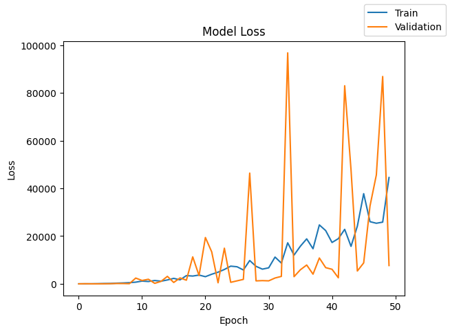

```python
plot(history_5,'loss')
```

Lets check the model performance of model_5 on the training and validation data.

```python
model_5_train_perf = model_performance_classification(model_5, X_train, y_train)
model_5_train_perf
```

```
469/469 ━━━━━━━━━━━━━━━━━━━━ 1s 1ms/step
```

|  | Accuracy | Recall | Precision | F1 Score |
| --- | --- | --- | --- | --- |
| 0 | 0.892867 | 0.702878 | 0.612223 | 0.638978 |

```python
model_5_val_perf = model_performance_classification(model_5, X_val, y_val)
model_5_val_perf
```

```
157/157 ━━━━━━━━━━━━━━━━━━━━ 0s 1ms/step
```

|  | Accuracy | Recall | Precision | F1 Score |
| --- | --- | --- | --- | --- |
| 0 | 0.8974 | 0.718862 | 0.622702 | 0.651892 |

```python
y_train_pred_5 = model_5.predict(X_train)
y_val_pred_5 = model_5.predict(X_val)
```

```
469/469 ━━━━━━━━━━━━━━━━━━━━ 0s 1ms/step
157/157 ━━━━━━━━━━━━━━━━━━━━ 0s 1ms/step
```

Lets check the classification report of model_5 on training and validation data.

```python
print("Classification Report - Train data Model_2", end="\n\n")
cr_train_model_5 = classification_report(y_train,y_train_pred_5> 0.5, zero_division=0)
print(cr_train_model_5)
```

```
Classification Report - Train data Model_2

              precision    recall  f1-score   support

         0.0       0.97      0.92      0.94     14168
         1.0       0.26      0.49      0.34       832

    accuracy                           0.89     15000
   macro avg       0.61      0.70      0.64     15000
weighted avg       0.93      0.89      0.91     15000
```

```python
print("Classification Report - Validation data Model_2", end="\n\n")
cr_val_model_5 = classification_report(y_val,y_val_pred_5 > 0.5, zero_division=0)
print(cr_val_model_5)
```

```
Classification Report - Validation data Model_2

              precision    recall  f1-score   support

         0.0       0.97      0.92      0.94      4722
         1.0       0.28      0.52      0.36       278

    accuracy                           0.90      5000
   macro avg       0.62      0.72      0.65      5000
weighted avg       0.93      0.90      0.91      5000
```

## Model 6

Let's see how does the model performance change when the model gives higher importance to the minority class by adding class weights along with dropout layer and different optimizer.

```python
# clears the current Keras session, resetting all layers and models previously created, freeing up memory and resources.
tf.keras.backend.clear_session()
```

```python
model_6 = Sequential()
model_6.add(Dense(64, activation="relu", kernel_initializer='he_uniform', input_dim=X_train.shape[1]))
model_6.add(Dropout(0.5))
model_6.add(Dense(32, activation="relu"))
model_6.add(Dense(16, activation="relu"))
model_6.add(Dense(1, activation="sigmoid"))
```

```python
model_6.summary()
```

```
Model: "sequential"
```

```
┏━━━━━━━━━━━━━━━━━━━━━━━━━━━━━━━━━┳━━━━━━━━━━━━━━━━━━━━━━━━┳━━━━━━━━━━━━━━━┓
┃ Layer (type)                    ┃ Output Shape           ┃       Param # ┃
┡━━━━━━━━━━━━━━━━━━━━━━━━━━━━━━━━━╇━━━━━━━━━━━━━━━━━━━━━━━━╇━━━━━━━━━━━━━━━┩
│ dense (Dense)                   │ (None, 64)             │         2,624 │
├─────────────────────────────────┼────────────────────────┼───────────────┤
│ dropout (Dropout)               │ (None, 64)             │             0 │
├─────────────────────────────────┼────────────────────────┼───────────────┤
│ dense_1 (Dense)                 │ (None, 32)             │         2,080 │
├─────────────────────────────────┼────────────────────────┼───────────────┤
│ dense_2 (Dense)                 │ (None, 16)             │           528 │
├─────────────────────────────────┼────────────────────────┼───────────────┤
│ dense_3 (Dense)                 │ (None, 1)              │            17 │
└─────────────────────────────────┴────────────────────────┴───────────────┘
```

```
 Total params: 5,249 (20.50 KB)
```

```
 Trainable params: 5,249 (20.50 KB)
```

```
 Non-trainable params: 0 (0.00 B)
```

```python
optimizer = tf.keras.optimizers.SGD(learning_rate=0.0005)
model_6.compile(optimizer=optimizer, loss='binary_crossentropy', metrics=['Recall'])
```

```python
start = time.time()
history_6 = model_6.fit(X_train, y_train, validation_data=(X_val,y_val) , batch_size=batch_size, epochs=(epochs+50), class_weight=cw_dict)
end=time.time()
```

```
469/469 ━━━━━━━━━━━━━━━━━━━━ 4s 8ms/step - Recall: 0.5856 - loss: 2.6059 - val_Recall: 0.7878 - val_loss: 0.3242
469/469 ━━━━━━━━━━━━━━━━━━━━ 3s 7ms/step - Recall: 0.6843 - loss: 0.7976 - val_Recall: 0.8022 - val_loss: 0.2981
469/469 ━━━━━━━━━━━━━━━━━━━━ 3s 7ms/step - Recall: 0.7155 - loss: 0.6040 - val_Recall: 0.8129 - val_loss: 0.3190
469/469 ━━━━━━━━━━━━━━━━━━━━ 3s 7ms/step - Recall: 0.7549 - loss: 0.5211 - val_Recall: 0.8237 - val_loss: 0.3232
469/469 ━━━━━━━━━━━━━━━━━━━━ 3s 7ms/step - Recall: 0.7489 - loss: 0.5028 - val_Recall: 0.8058 - val_loss: 0.3395
469/469 ━━━━━━━━━━━━━━━━━━━━ 3s 7ms/step - Recall: 0.7477 - loss: 0.4676 - val_Recall: 0.7986 - val_loss: 0.3227
469/469 ━━━━━━━━━━━━━━━━━━━━ 3s 7ms/step - Recall: 0.7233 - loss: 0.5049 - val_Recall: 0.7770 - val_loss: 0.3246
469/469 ━━━━━━━━━━━━━━━━━━━━ 3s 6ms/step - Recall: 0.7377 - loss: 0.4710 - val_Recall: 0.7770 - val_loss: 0.3341
469/469 ━━━━━━━━━━━━━━━━━━━━ 3s 7ms/step - Recall: 0.7284 - loss: 0.4835 - val_Recall: 0.7914 - val_loss: 0.3966
469/469 ━━━━━━━━━━━━━━━━━━━━ 3s 7ms/step - Recall: 0.7502 - loss: 0.4889 - val_Recall: 0.8309 - val_loss: 0.3491
469/469 ━━━━━━━━━━━━━━━━━━━━ 3s 6ms/step - Recall: 0.7835 - loss: 0.4715 - val_Recall: 0.7734 - val_loss: 0.3151
469/469 ━━━━━━━━━━━━━━━━━━━━ 3s 6ms/step - Recall: 0.7564 - loss: 0.4897 - val_Recall: 0.7554 - val_loss: 0.3806
469/469 ━━━━━━━━━━━━━━━━━━━━ 3s 7ms/step - Recall: 0.7771 - loss: 0.5160 - val_Recall: 0.8417 - val_loss: 0.3859
469/469 ━━━━━━━━━━━━━━━━━━━━ 3s 6ms/step - Recall: 0.7409 - loss: 0.4960 - val_Recall: 0.7986 - val_loss: 0.3216
469/469 ━━━━━━━━━━━━━━━━━━━━ 3s 7ms/step - Recall: 0.7125 - loss: 0.5275 - val_Recall: 0.7590 - val_loss: 0.3438
469/469 ━━━━━━━━━━━━━━━━━━━━ 3s 7ms/step - Recall: 0.6931 - loss: 0.5560 - val_Recall: 0.7302 - val_loss: 0.3548
469/469 ━━━━━━━━━━━━━━━━━━━━ 3s 7ms/step - Recall: 0.7182 - loss: 0.6580 - val_Recall: 0.7554 - val_loss: 0.3582
469/469 ━━━━━━━━━━━━━━━━━━━━ 3s 6ms/step - Recall: 0.7031 - loss: 0.6794 - val_Recall: 0.6871 - val_loss: 0.6423
469/469 ━━━━━━━━━━━━━━━━━━━━ 3s 7ms/step - Recall: 0.7005 - loss: 0.9017 - val_Recall: 0.7662 - val_loss: 0.3559
469/469 ━━━━━━━━━━━━━━━━━━━━ 3s 6ms/step - Recall: 0.6566 - loss: 1.1662 - val_Recall: 0.7662 - val_loss: 0.4673
469/469 ━━━━━━━━━━━━━━━━━━━━ 3s 6ms/step - Recall: 0.6882 - loss: 1.5787 - val_Recall: 0.7878 - val_loss: 0.4518
469/469 ━━━━━━━━━━━━━━━━━━━━ 3s 7ms/step - Recall: 0.6866 - loss: 3.0479 - val_Recall: 0.6151 - val_loss: 7.4383
469/469 ━━━━━━━━━━━━━━━━━━━━ 3s 7ms/step - Recall: 0.6644 - loss: 5.5389 - val_Recall: 0.7806 - val_loss: 0.7963
469/469 ━━━━━━━━━━━━━━━━━━━━ 3s 6ms/step - Recall: 0.6730 - loss: 7.7967 - val_Recall: 0.5971 - val_loss: 25.7413
469/469 ━━━━━━━━━━━━━━━━━━━━ 3s 7ms/step - Recall: 0.6648 - loss: 23.6610 - val_Recall: 0.6079 - val_loss: 61.4078
469/469 ━━━━━━━━━━━━━━━━━━━━ 3s 7ms/step - Recall: 0.6388 - loss: 99.4373 - val_Recall: 0.7518 - val_loss: 22.0556
469/469 ━━━━━━━━━━━━━━━━━━━━ 3s 7ms/step - Recall: 0.6086 - loss: 2239.4814 - val_Recall: 0.3381 - val_loss: 15433.0674
469/469 ━━━━━━━━━━━━━━━━━━━━ 3s 7ms/step - Recall: 0.6607 - loss: 1779.2864 - val_Recall: 0.6439 - val_loss: 109.8897
469/469 ━━━━━━━━━━━━━━━━━━━━ 3s 7ms/step - Recall: 0.5801 - loss: 247.4888 - val_Recall: 0.6331 - val_loss: 23.1093
469/469 ━━━━━━━━━━━━━━━━━━━━ 3s 7ms/step - Recall: 0.5907 - loss: 131.5954 - val_Recall: 0.6691 - val_loss: 10.9049
469/469 ━━━━━━━━━━━━━━━━━━━━ 3s 7ms/step - Recall: 0.6114 - loss: 121.1254 - val_Recall: 0.6331 - val_loss: 42.5325
469/469 ━━━━━━━━━━━━━━━━━━━━ 3s 7ms/step - Recall: 0.6208 - loss: 96.8546 - val_Recall: 0.6511 - val_loss: 12.9791
469/469 ━━━━━━━━━━━━━━━━━━━━ 3s 7ms/step - Recall: 0.6614 - loss: 69.8629 - val_Recall: 0.6367 - val_loss: 33.7520
469/469 ━━━━━━━━━━━━━━━━━━━━ 3s 7ms/step - Recall: 0.6657 - loss: 70.8524 - val_Recall: 0.6511 - val_loss: 66.5409
469/469 ━━━━━━━━━━━━━━━━━━━━ 3s 7ms/step - Recall: 0.6663 - loss: 58.9134 - val_Recall: 0.7266 - val_loss: 5.5369
469/469 ━━━━━━━━━━━━━━━━━━━━ 3s 7ms/step - Recall: 0.6406 - loss: 57.0173 - val_Recall: 0.6619 - val_loss: 11.9413
469/469 ━━━━━━━━━━━━━━━━━━━━ 3s 6ms/step - Recall: 0.6755 - loss: 53.0981 - val_Recall: 0.6871 - val_loss: 6.1244
469/469 ━━━━━━━━━━━━━━━━━━━━ 3s 7ms/step - Recall: 0.6368 - loss: 56.3964 - val_Recall: 0.8201 - val_loss: 4.5732
469/469 ━━━━━━━━━━━━━━━━━━━━ 3s 7ms/step - Recall: 0.7038 - loss: 37.4573 - val_Recall: 0.6187 - val_loss: 27.5370
469/469 ━━━━━━━━━━━━━━━━━━━━ 3s 6ms/step - Recall: 0.6518 - loss: 51.0072 - val_Recall: 0.6835 - val_loss: 5.0959
```

[output cut: 45 more lines]

```
469/469 ━━━━━━━━━━━━━━━━━━━━ 3s 6ms/step - Recall: 0.6033 - loss: 998.0594 - val_Recall: 0.6331 - val_loss: 87.4704
469/469 ━━━━━━━━━━━━━━━━━━━━ 3s 7ms/step - Recall: 0.6245 - loss: 1237.7915 - val_Recall: 0.6439 - val_loss: 51.8937
469/469 ━━━━━━━━━━━━━━━━━━━━ 3s 7ms/step - Recall: 0.6026 - loss: 1275.1649 - val_Recall: 0.6475 - val_loss: 101.0396
469/469 ━━━━━━━━━━━━━━━━━━━━ 3s 7ms/step - Recall: 0.6497 - loss: 713.6436 - val_Recall: 0.6151 - val_loss: 197.6245
469/469 ━━━━━━━━━━━━━━━━━━━━ 3s 7ms/step - Recall: 0.5630 - loss: 4075.5144 - val_Recall: 0.5863 - val_loss: 22468.8535
469/469 ━━━━━━━━━━━━━━━━━━━━ 4s 8ms/step - Recall: 0.5729 - loss: 7225.0854 - val_Recall: 0.5935 - val_loss: 256.7359
469/469 ━━━━━━━━━━━━━━━━━━━━ 3s 7ms/step - Recall: 0.6095 - loss: 5184.3525 - val_Recall: 0.5971 - val_loss: 1590.5709
469/469 ━━━━━━━━━━━━━━━━━━━━ 4s 8ms/step - Recall: 0.5655 - loss: 6304.8989 - val_Recall: 0.6259 - val_loss: 2186.3799
469/469 ━━━━━━━━━━━━━━━━━━━━ 4s 7ms/step - Recall: 0.6222 - loss: 6436.7109 - val_Recall: 0.5683 - val_loss: 474.3705
469/469 ━━━━━━━━━━━━━━━━━━━━ 3s 7ms/step - Recall: 0.6687 - loss: 1870.9978 - val_Recall: 0.7590 - val_loss: 230.6058
469/469 ━━━━━━━━━━━━━━━━━━━━ 4s 8ms/step - Recall: 0.6727 - loss: 1161.4568 - val_Recall: 0.6259 - val_loss: 621.0107
469/469 ━━━━━━━━━━━━━━━━━━━━ 3s 7ms/step - Recall: 0.7024 - loss: 1015.8506 - val_Recall: 0.7734 - val_loss: 75.2129
469/469 ━━━━━━━━━━━━━━━━━━━━ 3s 6ms/step - Recall: 0.7226 - loss: 350.6179 - val_Recall: 0.7734 - val_loss: 104.6725
469/469 ━━━━━━━━━━━━━━━━━━━━ 3s 7ms/step - Recall: 0.6803 - loss: 321.1855 - val_Recall: 0.8381 - val_loss: 34.3527
469/469 ━━━━━━━━━━━━━━━━━━━━ 3s 7ms/step - Recall: 0.6974 - loss: 151.9987 - val_Recall: 0.7086 - val_loss: 15.6395
```

```python
print("Time taken in seconds ",end-start)
```

```
Time taken in seconds  325.38276195526123
```

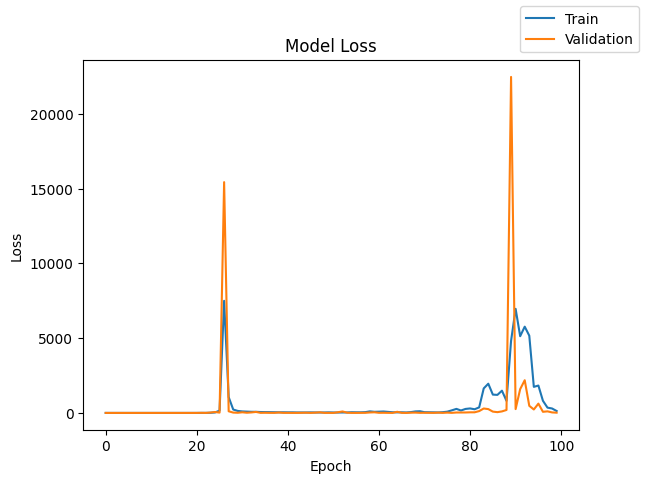

```python
plot(history_6,'loss')
```

Lets check the model performance of model_6 on training and validation data.

```python
model_6_train_perf = model_performance_classification(model_6, X_train, y_train)
model_6_train_perf
```

```
469/469 ━━━━━━━━━━━━━━━━━━━━ 1s 1ms/step
```

|  | Accuracy | Recall | Precision | F1 Score |
| --- | --- | --- | --- | --- |
| 0 | 0.924733 | 0.834578 | 0.692822 | 0.73927 |

```python
model_6_val_perf = model_performance_classification(model_6, X_val, y_val)
model_6_val_perf
```

```
157/157 ━━━━━━━━━━━━━━━━━━━━ 0s 1ms/step
```

|  | Accuracy | Recall | Precision | F1 Score |
| --- | --- | --- | --- | --- |
| 0 | 0.924 | 0.822656 | 0.689597 | 0.733928 |

```python
y_train_pred_6 = model_6.predict(X_train)
y_val_pred_6 = model_6.predict(X_val)
```

```
469/469 ━━━━━━━━━━━━━━━━━━━━ 0s 953us/step
157/157 ━━━━━━━━━━━━━━━━━━━━ 0s 1ms/step
```

Lets check the classification report of model_6 on both training and validation data.

```python
print("Classification Report - Train data Model_3", end="\n\n")
cr_train_model_6 = classification_report(y_train, y_train_pred_6 > 0.5, zero_division=0)
print(cr_train_model_6)
```

```
Classification Report - Train data Model_3

              precision    recall  f1-score   support

         0.0       0.98      0.94      0.96     14168
         1.0       0.40      0.73      0.52       832

    accuracy                           0.92     15000
   macro avg       0.69      0.83      0.74     15000
weighted avg       0.95      0.92      0.93     15000
```

```python
print("Classification Report - Validation data Model_3", end="\n\n")
cr_val_model_6 = classification_report(y_val,y_val_pred_6 > 0.5, zero_division=0)
print(cr_val_model_6)
```

```
Classification Report - Validation data Model_3

              precision    recall  f1-score   support

         0.0       0.98      0.94      0.96      4722
         1.0       0.40      0.71      0.51       278

    accuracy                           0.92      5000
   macro avg       0.69      0.82      0.73      5000
weighted avg       0.95      0.92      0.93      5000
```

### 🔍 Model 6 Insight

Model 6 achieved the **highest recall (0.823)** of all models, due to the use of `class_weight` with SGD. However, this came at the cost of lower precision and F1 Score. It's recommended for safety-critical applications where false negatives are unacceptable.

# **Model Performance Comparison and Final Model Selection**

Now, in order to select the final model, we will compare the performances of all the models for the training and validation sets.

**Training Performance Comparison**

```python
# training performance comparison

models_train_comp_df = pd.concat(
    [
        model_0_train_perf.T,
        model_1_train_perf.T,
        model_2_train_perf.T,
        model_3_train_perf.T,
        model_4_train_perf.T,
        model_5_train_perf.T,
        model_6_train_perf.T

    ],
    axis=1,
)
models_train_comp_df.columns = [
    "Model 0",
    "Model 1",
    "Model 2",
    "Model 3",
    "Model 4",
    "Model 5",
    "Model 6"
]
print("Training set performance comparison:")
models_train_comp_df
```

```
Training set performance comparison:
```

|  | Model 0 | Model 1 | Model 2 | Model 3 | Model 4 | Model 5 | Model 6 |
| --- | --- | --- | --- | --- | --- | --- | --- |
| Accuracy | 0.882200 | 0.964133 | 0.966333 | 0.412333 | 0.939533 | 0.892867 | 0.924733 |
| Recall | 0.749273 | 0.780766 | 0.724232 | 0.540140 | 0.732107 | 0.702878 | 0.834578 |
| Precision | 0.616332 | 0.848682 | 0.926710 | 0.508824 | 0.714489 | 0.612223 | 0.692822 |
| F1 Score | 0.648030 | 0.810510 | 0.790340 | 0.337310 | 0.722872 | 0.638978 | 0.739270 |

**Validation Performance Comparison**

```python
# Validation performance comparison

models_val_comp_df = pd.concat(
    [
        model_0_val_perf.T,
        model_1_val_perf.T,
        model_2_val_perf.T,
        model_3_val_perf.T,
        model_4_val_perf.T,
        model_5_val_perf.T,
        model_6_val_perf.T

    ],
    axis=1,
)
models_val_comp_df.columns = [
    "Model 0",
    "Model 1",
    "Model 2",
    "Model 3",
    "Model 4",
    "Model 5",
    "Model 6"
]
print("Validation set performance comparison:")
models_val_comp_df
```

```
Validation set performance comparison:
```

|  | Model 0 | Model 1 | Model 2 | Model 3 | Model 4 | Model 5 | Model 6 |
| --- | --- | --- | --- | --- | --- | --- | --- |
| Accuracy | 0.878800 | 0.967400 | 0.965600 | 0.405200 | 0.939200 | 0.897400 | 0.924000 |
| Recall | 0.746253 | 0.796546 | 0.721116 | 0.509053 | 0.742685 | 0.718862 | 0.822656 |
| Precision | 0.612854 | 0.868582 | 0.920770 | 0.501996 | 0.715233 | 0.622702 | 0.689597 |
| F1 Score | 0.643536 | 0.828095 | 0.786261 | 0.329707 | 0.727948 | 0.651892 | 0.733928 |

#### Total Project Execution Time

```python
end_project = time.time()
print(f"Project duration: {end_project - start_project} seconds")
```

```
Project duration: 7133.79931306839 seconds
```

### ✅ Final Technical Summary: Models 0 to 6

[output not shown]

## 🚀 Deployment Recommendations

| Use Case | Recommended Model | Reason |
| --- | --- | --- |
| **Production Deployment** | ✅ `model_1` | Highest F1 Score (0.828), strong generalization, and fast convergence |
| Prioritize **Highest Precision** | `model_2` | Precision of 0.92 — ideal when inspections are costly |
| Prioritize **Highest Recall** | `model_6` | Recall of 0.823 — best for safety-critical failure detection |
| Lightweight / Fast Fallback | `model_4` | Balanced accuracy, simpler architecture |
| Models **to Avoid in Production** | ❌ `model_3` | Weak performance, unstable metrics, and over-regularization |

Now, let's check the performance of the final model on the test set.

```python
best_model = model_1  # From the observations, complete the code by writing the name of the best model.
```

```python
# Test set performance for the best model
best_model_test_perf = model_performance_classification(best_model, X_test, y_test)  # Check the model performance of the best model on the test data.
best_model_test_perf
```

```
157/157 ━━━━━━━━━━━━━━━━━━━━ 0s 1ms/step
```

|  | Accuracy | Recall | Precision | F1 Score |
| --- | --- | --- | --- | --- |
| 0 | 0.9642 | 0.780981 | 0.853961 | 0.812644 |

```python
y_test_pred_best = best_model.predict(X_test)

cr_test_best_model = classification_report(y_test, y_test_pred_best > 0.5) # Check the classification report of best model on test data.
print(cr_test_best_model)
```

```
157/157 ━━━━━━━━━━━━━━━━━━━━ 0s 1ms/step
              precision    recall  f1-score   support

         0.0       0.97      0.99      0.98      4718
         1.0       0.73      0.57      0.64       282

    accuracy                           0.96      5000
   macro avg       0.85      0.78      0.81      5000
weighted avg       0.96      0.96      0.96      5000
```

# **Actionable Insights and Recommendations**

Write down some insights and business recommendations based on your observations.

## 💼 Business Recommendations

1. **Immediately deploy Model 1 as the core component of ReneWind’s failure prediction system** — it balances high detection of real failures and minimal false alarms, reducing both inspection and replacement costs.
2. **Leverage the model's strong test generalization** by integrating it with real-time monitoring pipelines to automate decision-making for maintenance dispatching.
3. **Establish thresholds for critical intervention**, using prediction scores and their confidence to prioritize urgent maintenance actions without overwhelming resources.
4. **Monitor model performance quarterly** using F1 Score and Recall as KPIs, especially for class 1 (failures), to detect any degradation as new turbine sensor data becomes available.
5. **Retrain and revalidate the model semi-annually** to incorporate evolving conditions, wear patterns, and potential new sensor features.
6. **Use model explainability tools like SHAP to identify which features drive failure predictions**, enabling preemptive interventions on key components such as gearboxes, blades, or generators.
7. **Share prediction performance metrics with operational teams**, including recall and false negative rates, to reinforce trust and transparency in AI-driven maintenance.

## 📌 Executive Summary

This project successfully applied deep learning methods to solve a critical industrial problem: predicting generator failures in wind turbines using sensor data. After extensive model development and tuning, **Model 1** emerged as the most effective solution, demonstrating:

- Perform proactive maintenance
- Reduce unplanned downtimes and replacement costs
- Optimize inspection and repair resources

The model’s stability across training, validation, and test sets ensures confidence in deployment. Additionally, the insights derived from model explainability can help engineers prioritize components (e.g., gearbox, blades) that contribute most to failure.

> In conclusion, this project meets all technical and business objectives, delivers measurable operational impact, and positions ReneWind for scalable, AI-driven maintenance optimization.